# Ortolans & oilplants

```r
#jos luottamusvälien sisälle mahtuu nolla, ei muuttuja ole "merkitsevä", tai siis sen vaikutus on pieni eikä edes sen
#merkkiä (negatiivinen vai positiivinen) pysty arvioimaan luotettavasti.
#year, Ariver, agri5, region, NeoPrior ja  temp selittävät osansa reviirien määrän vaihtelusta

#taulukkoa taas yritän tehdä..
ma_coefs <- coefTable(ave, full=F, adjust.se = TRUE)
coefnames <- row.names(ma_coefs)
ma_coefs <- as.data.frame(ma_coefs)
ma_coefs <- mutate(ma_coefs,
                   coefficient = coefnames,
                   t = Estimate / `Std. Error`,
                   p = pt(abs(t), df = 1397, lower.tail = FALSE), #en tiedä onko df oikein. Mutta sen muuttaminen ei muuta tuloksia?!
                   lower95 = Estimate - 1.96 * `Std. Error`,
                   upper95 = Estimate + 1.96 * `Std. Error`) %>% select(coefficient, Estimate, `Std. Error`, t, p, lower95, upper95)
knitr::kable(ma_coefs, digits = 2)
```

| coefficient | Estimate | Std. Error | t | p | lower95 | upper95 |
| --- | --- | --- | --- | --- | --- | --- |
| cond((Int)) | -0.38 | 0.31 | -1.21 | 0.11 | -0.99 | 0.24 |
| cond(year) | -0.96 | 0.13 | -7.34 | 0.00 | -1.22 | -0.71 |
| cond(Abuild) | -0.16 | 0.17 | -0.93 | 0.18 | -0.49 | 0.17 |
| cond(Aroad) | 0.24 | 0.16 | 1.54 | 0.06 | -0.07 | 0.55 |
| cond(Astream) | 0.07 | 0.13 | 0.55 | 0.29 | -0.18 | 0.33 |
| cond(Ariver) | 0.30 | 0.12 | 2.48 | 0.01 | 0.06 | 0.54 |
| cond(agri5) | 0.56 | 0.14 | 3.85 | 0.00 | 0.27 | 0.84 |
| cond(regionLOU) | 1.48 | 0.35 | 4.19 | 0.00 | 0.79 | 2.17 |
| cond(regionPOH) | 1.99 | 0.39 | 5.07 | 0.00 | 1.22 | 2.76 |
| cond(regionUUS) | 1.47 | 0.34 | 4.31 | 0.00 | 0.80 | 2.14 |
| cond(NeoPrior) | -0.13 | 0.06 | -2.06 | 0.02 | -0.26 | -0.01 |
| cond(temp) | 0.14 | 0.05 | 2.97 | 0.00 | 0.05 | 0.23 |
| cond(prec) | -0.05 | 0.05 | -1.01 | 0.16 | -0.14 | 0.04 |
| cond(NeoPrior:year) | 0.03 | 0.13 | 0.20 | 0.42 | -0.24 | 0.29 |
| cond(temp:year) | 0.08 | 0.10 | 0.85 | 0.20 | -0.11 | 0.28 |
| cond(prec:year) | -0.15 | 0.08 | -1.79 | 0.04 | -0.31 | 0.01 |

```r
coef=ma_coefs
coef$coefficient=factor(coef$coefficient)
coef$signi=factor(ifelse(coef$p >= 0.035 , 'N', 'Y'))
```

Piirrän kuvaajia regressiokertoimista ja niiden luottamusvälit

Regressiokertoimet ja niiden SE:t

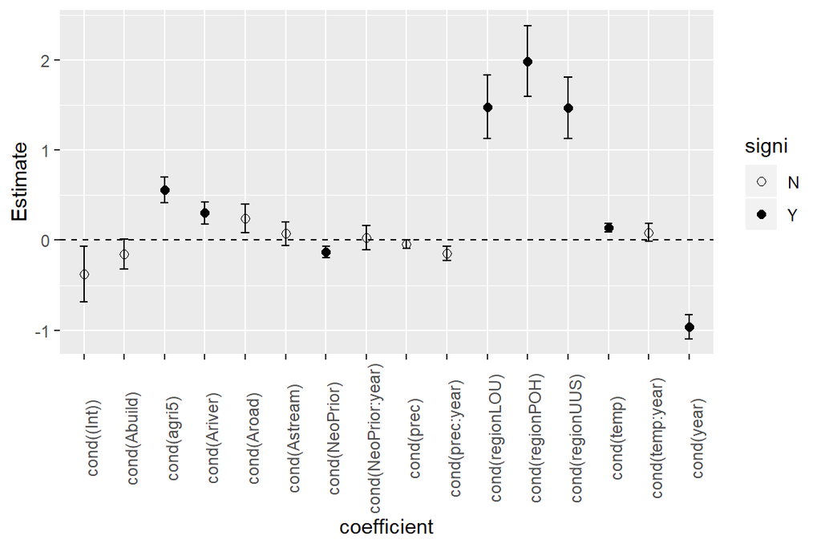

```r
ggplot(data= coef, aes(coefficient, Estimate,group=signi)) +
  geom_point(aes(shape=signi), size=2) + scale_shape_manual(values=c(1,16)) +
  geom_errorbar(data = coef, aes(coefficient, Estimate, ymin=Estimate - `Std. Error`, ymax = Estimate + `Std. Error`), width=0.2) +
  theme(axis.text.x = element_text(angle = 90)) +
  geom_hline(yintercept=0,linetype="dashed")
```

Regressiokertoimet ja niiden 95% luottamusvälit

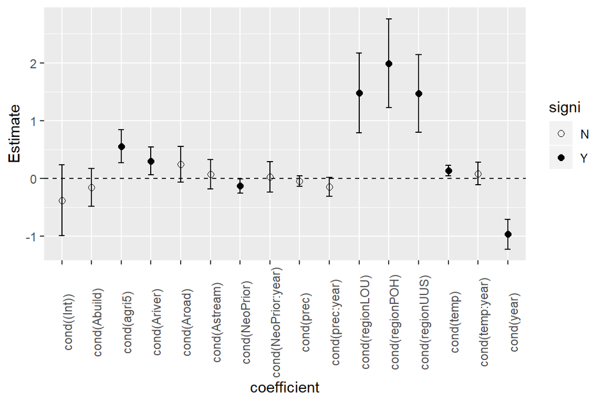

```r
ggplot(data= coef, aes(coefficient, Estimate,group=signi)) +
  geom_point(aes(shape=signi), size=2) + scale_shape_manual(values=c(1,16)) +
  geom_errorbar(data = coef, aes(coefficient, Estimate, ymin=lower95, ymax = upper95), width=0.2) +
  theme(axis.text.x = element_text(angle = 90)) +
  geom_hline(yintercept=0,linetype="dashed")
```

## ennusteet predict-funktiolla

```r
##############################################################################
#yritän tehdä ennusteita model averaged mallilla

newdata <- expand.grid(NeoPrior= with(dataS, seq(0.1, 0.9, length.out=3)),
                       year = mean(dataS$year),
                       Abuild = mean(dataS$Abuild),
                       Aroad = mean(dataS$Aroad),
                        Astream = mean(dataS$Astream),
                        Ariver = mean(dataS$Ariver),
                        agri5 = mean(dataS$agri5),
                        region = levels(dataS$region),
                        temp = mean(dataS$temp),
                        prec = mean(dataS$prec),
                        temp = mean(dataS$temp),
                       Larea=mean(dataS$Larea)) #tarviiko tämän?

pred.se <- predict(ave, type="link", re.form=NA,se.fit=TRUE, full=T, newdata) #ERROR: re.form not yet implemented
```

```
## Error in predict.glmmTMB(object = structure(list(obj = list(par = c(beta = 0, : re.form not yet implemented
```

Predict-funktio ei toimi glmmTMB-funktion tuottaman keskiarvoistetun malliobjektin kanssa yhteen. Täytyy kokeilla jotain toista pakettia tai funktiota mallien sovittamiseen. Tai kokeilen tehdä ennusteet käsin.

## ennusteet käsin

Seuraan esimerkkiä tästä [paperista](https://onlinelibrary.wiley.com/doi/full/10.1111/j.1420-9101.2010.02210.x).

```r
#seuraavaksi ajattelin jatkaa paperin esimerkin mukaan ja käyttää model averaged mallia
#piste-ennusteiden tekemiseen

#Lasken kullekin alueelle ennustetut reviirimäärät kun NeoPrior-arvot ovat 0.1, 0.5 tai 0.9

year=0;Abuild=0;Aroad=0;Astream=0;Ariver=0;agri5=0;temp=0;prec=0;LOU=0;POH=0;UUS=0;NeoPrior=0.1

TerriETHlow= -0.38 - 0.97*year - 0.16*Abuild + 0.24*Aroad + 0.07*Astream + 0.30*Ariver + 0.56*agri5 +1.48*LOU+
  1.99*POH + 1.47*UUS - 0.13*((NeoPrior-0.069)/(2*0.115447)) + 0.14*temp - 0.05*prec + 0.03*year*NeoPrior + 0.08*temp*year -
  0.15*prec*year+ mean(dataS$Larea)
TerriETHlow
```

```
## [1] -0.9329908
```

```r
a=exp(TerriETHlow)

year=0;Abuild=0;Aroad=0;Astream=0;Ariver=0;agri5=0;temp=0;prec=0;LOU=0;POH=0;UUS=1;NeoPrior=0.1

TerriUUSlow= -0.38 - 0.97*year - 0.16*Abuild + 0.24*Aroad + 0.07*Astream + 0.30*Ariver + 0.56*agri5 +1.48*LOU+
  1.99*POH + 1.47*UUS - 0.13*((NeoPrior-0.069)/(2*0.115447)) + 0.14*temp - 0.05*prec + 0.03*year*NeoPrior + 0.08*temp*year -
  0.15*prec*year+ mean(dataS$Larea)
TerriUUSlow
```

```
## [1] 0.5370092
```

```r
b=exp(TerriUUSlow)

year=0;Abuild=0;Aroad=0;Astream=0;Ariver=0;agri5=0;temp=0;prec=0;LOU=0;POH=1;UUS=0;NeoPrior=0.1

TerriPOHlow= -0.38 - 0.97*year - 0.16*Abuild + 0.24*Aroad + 0.07*Astream + 0.30*Ariver + 0.56*agri5 +1.48*LOU+
  1.99*POH + 1.47*UUS - 0.13*((NeoPrior-0.069)/(2*0.115447)) + 0.14*temp - 0.05*prec + 0.03*year*NeoPrior + 0.08*temp*year -
  0.15*prec*year+ mean(dataS$Larea)
TerriPOHlow
```

```
## [1] 1.057009
```

```r
c=exp(TerriPOHlow)

year=0;Abuild=0;Aroad=0;Astream=0;Ariver=0;agri5=0;temp=0;prec=0;LOU=1;POH=0;UUS=0;NeoPrior=0.1

TerriLOUlow= -0.38 - 0.97*year - 0.16*Abuild + 0.24*Aroad + 0.07*Astream + 0.30*Ariver + 0.56*agri5 +1.48*LOU+
  1.99*POH + 1.47*UUS - 0.13*((NeoPrior-0.069)/(2*0.115447)) + 0.14*temp - 0.05*prec + 0.03*year*NeoPrior + 0.08*temp*year -
  0.15*prec*year+ mean(dataS$Larea)
TerriLOUlow
```

```
## [1] 0.5470092
```

```r
d=exp(TerriLOUlow)


NeoPrior0.1=cbind(a,b,c,d)
NeoPrior0.1
```

```
##              a        b        c        d
## [1,] 0.3933754 1.710882 2.877751 1.728077
```

```r
#########################

year=0;Abuild=0;Aroad=0;Astream=0;Ariver=0;agri5=0;temp=0;prec=0;LOU=0;POH=0;UUS=0;NeoPrior=0.5

TerriETHmed= -0.38 - 0.97*year - 0.16*Abuild + 0.24*Aroad + 0.07*Astream + 0.30*Ariver + 0.56*agri5 +1.48*LOU+
  1.99*POH + 1.47*UUS - 0.13*((NeoPrior-0.069)/(2*0.115447)) + 0.14*temp - 0.05*prec + 0.03*year*NeoPrior + 0.08*temp*year - 0.15*prec*year + mean(dataS$Larea)
TerriETHmed
```

```
## [1] -1.158202
```

```r
a=exp(TerriETHmed)

year=0;Abuild=0;Aroad=0;Astream=0;Ariver=0;agri5=0;temp=0;prec=0;LOU=0;POH=0;UUS=1;NeoPrior=0.5

TerriUUSmed= -0.38 - 0.97*year - 0.16*Abuild + 0.24*Aroad + 0.07*Astream + 0.30*Ariver + 0.56*agri5 +1.48*LOU+
  1.99*POH + 1.47*UUS - 0.13*((NeoPrior-0.069)/(2*0.115447)) + 0.14*temp - 0.05*prec + 0.03*year*NeoPrior + 0.08*temp*year -
  0.15*prec*year+ mean(dataS$Larea)
TerriUUSmed
```

```
## [1] 0.3117976
```

```r
b=exp(TerriUUSmed)

year=0;Abuild=0;Aroad=0;Astream=0;Ariver=0;agri5=0;temp=0;prec=0;LOU=0;POH=1;UUS=0;NeoPrior=0.5

TerriPOHmed= -0.38 - 0.97*year - 0.16*Abuild + 0.24*Aroad + 0.07*Astream + 0.30*Ariver + 0.56*agri5 +1.48*LOU+
  1.99*POH + 1.47*UUS - 0.13*((NeoPrior-0.069)/(2*0.115447)) + 0.14*temp - 0.05*prec + 0.03*year*NeoPrior + 0.08*temp*year -
  0.15*prec*year+ mean(dataS$Larea)
TerriPOHmed
```

```
## [1] 0.8317976
```

```r
c=exp(TerriPOHmed)

year=0;Abuild=0;Aroad=0;Astream=0;Ariver=0;agri5=0;temp=0;prec=0;LOU=1;POH=0;UUS=0;NeoPrior=0.5

TerriLOUmed= -0.38 - 0.97*year - 0.16*Abuild + 0.24*Aroad + 0.07*Astream + 0.30*Ariver + 0.56*agri5 +1.48*LOU+
  1.99*POH + 1.47*UUS - 0.13*((NeoPrior-0.069)/(2*0.115447)) + 0.14*temp - 0.05*prec + 0.03*year*NeoPrior + 0.08*temp*year -
  0.15*prec*year+ mean(dataS$Larea)
TerriLOUmed
```

```
## [1] 0.3217976
```

```r
d=exp(TerriLOUmed)


NeoPrior0.5=cbind(a,b,c,d)
NeoPrior0.5
```

```
##              a        b        c        d
## [1,] 0.3140502 1.365878 2.297445 1.379606
```

```r
#########################

year=0;Abuild=0;Aroad=0;Astream=0;Ariver=0;agri5=0;temp=0;prec=0;LOU=0;POH=0;UUS=0;NeoPrior=0.9

TerriETHhigh= -0.38 - 0.97*year - 0.16*Abuild + 0.24*Aroad + 0.07*Astream + 0.30*Ariver + 0.56*agri5 +1.48*LOU+
  1.99*POH + 1.47*UUS - 0.13*((NeoPrior-0.069)/(2*0.115447)) + 0.14*temp - 0.05*prec + 0.03*year*NeoPrior + 0.08*temp*year -
  0.15*prec*year+ mean(dataS$Larea)
TerriETHhigh
```

```
## [1] -1.383414
```

```r
a=exp(TerriETHhigh)

year=0;Abuild=0;Aroad=0;Astream=0;Ariver=0;agri5=0;temp=0;prec=0;LOU=0;POH=0;UUS=1;NeoPrior=0.9

TerriUUShigh= -0.38 - 0.97*year - 0.16*Abuild + 0.24*Aroad + 0.07*Astream + 0.30*Ariver + 0.56*agri5 +1.48*LOU+
  1.99*POH + 1.47*UUS - 0.13*((NeoPrior-0.069)/(2*0.115447)) + 0.14*temp - 0.05*prec + 0.03*year*NeoPrior + 0.08*temp*year -
  0.15*prec*year+ mean(dataS$Larea)
TerriUUShigh
```

```
## [1] 0.08658604
```

```r
b=exp(TerriUUShigh)

year=0;Abuild=0;Aroad=0;Astream=0;Ariver=0;agri5=0;temp=0;prec=0;LOU=0;POH=1;UUS=0;NeoPrior=0.9

TerriPOHhigh= -0.38 - 0.97*year - 0.16*Abuild + 0.24*Aroad + 0.07*Astream + 0.30*Ariver + 0.56*agri5 +1.48*LOU+
  1.99*POH + 1.47*UUS - 0.13*((NeoPrior-0.069)/(2*0.115447)) + 0.14*temp - 0.05*prec + 0.03*year*NeoPrior + 0.08*temp*year -
  0.15*prec*year+ mean(dataS$Larea)
TerriPOHhigh
```

```
## [1] 0.606586
```

```r
c=exp(TerriPOHhigh)

year=0;Abuild=0;Aroad=0;Astream=0;Ariver=0;agri5=0;temp=0;prec=0;LOU=1;POH=0;UUS=0;NeoPrior=0.9

TerriLOUhigh= -0.38 - 0.97*year - 0.16*Abuild + 0.24*Aroad + 0.07*Astream + 0.30*Ariver + 0.56*agri5 +1.48*LOU+
  1.99*POH + 1.47*UUS - 0.13*((NeoPrior-0.069)/(2*0.115447)) + 0.14*temp - 0.05*prec + 0.03*year*NeoPrior + 0.08*temp*year -
  0.15*prec*year+ mean(dataS$Larea)
TerriLOUhigh
```

```
## [1] 0.09658604
```

```r
d=exp(TerriLOUhigh)


NeoPrior0.9=cbind(a,b,c,d)
NeoPrior0.9
```

```
##              a        b        c        d
## [1,] 0.2507211 1.090445 1.834159 1.101404
```

```r
Neth=sum(dataS$region=="ETH")
Nlou=sum(dataS$region=="LOU")
Nuus=sum(dataS$region=="UUS")
Npoh=sum(dataS$region=="POH")
Ntot=Neth+Nlou+Nuus+Npoh

#Kaikkien alueiden yli laskettu ennustettu reviirimäärä kullekin neo-arvolle:

terri0.1=(TerriETHlow*Neth + TerriUUSlow*Nuus + TerriPOHlow*Npoh + TerriLOUlow*Nlou)/Ntot
exp(terri0.1)
```

```
## [1] 1.489756
```

```r
terri0.5=(TerriETHmed*Neth + TerriUUSmed*Nuus + TerriPOHmed*Npoh + TerriLOUmed*Nlou)/Ntot
exp(terri0.5)
```

```
## [1] 1.189343
```

```r
terri0.9=(TerriETHhigh*Neth + TerriUUShigh*Nuus + TerriPOHhigh*Npoh + TerriLOUhigh*Nlou)/Ntot
exp(terri0.9)
```

```
## [1] 0.9495084
```

```r
enn=c(exp(terri0.1),exp(terri0.5),exp(terri0.9))
enn
```

```
## [1] 1.4897559 1.1893426 0.9495084
```

```r
kasit=c("low","med","high")
ennusteet=data.frame(enn,kasit)
ennusteet
```

```
##         enn kasit
## 1 1.4897559   low
## 2 1.1893426   med
## 3 0.9495084  high
```

```r
preds=c(NeoPrior0.1,NeoPrior0.5,NeoPrior0.9)
preds
```

```
##  [1] 0.3933754 1.7108823 2.8777513 1.7280769 0.3140502 1.3658782 2.2974449
##  [8] 1.3796055 0.2507211 1.0904452 1.8341589 1.1014043
```

```r
treat=rep(c("low","med","high"),each=4)
treat
```

```
##  [1] "low"  "low"  "low"  "low"  "med"  "med"  "med"  "med"  "high" "high"
## [11] "high" "high"
```

```r
region=rep(c("ETH","UUS","POH","LOU"),times=3)
region
```

```
##  [1] "ETH" "UUS" "POH" "LOU" "ETH" "UUS" "POH" "LOU" "ETH" "UUS" "POH"
## [12] "LOU"
```

```r
predictions=data.frame(preds,treat,region)
predictions
```

```
##        preds treat region
## 1  0.3933754   low    ETH
## 2  1.7108823   low    UUS
## 3  2.8777513   low    POH
## 4  1.7280769   low    LOU
## 5  0.3140502   med    ETH
## 6  1.3658782   med    UUS
## 7  2.2974449   med    POH
## 8  1.3796055   med    LOU
## 9  0.2507211  high    ETH
## 10 1.0904452  high    UUS
## 11 1.8341589  high    POH
## 12 1.1014043  high    LOU
```

### Luottamusvälit ennusteille

```r
#luottamusvälien laskeminen

year=0;Abuild=0;Aroad=0;Astream=0;Ariver=0;agri5=0;temp=0;prec=0;LOU=0;POH=0;UUS=0;NeoPrior=0.1

#luottamusvälin ala-arvo
confETHlow= -0.99 - 1.22*year - 0.48*Abuild - 0.07*Aroad - 0.19*Astream + 0.06*Ariver + 0.27*agri5 +0.79*LOU+
  1.22*POH + 0.80*UUS - 0.25*((NeoPrior-0.069)/(2*0.115447)) + 0.05*temp - 0.14*prec - 0.24*year*NeoPrior - 0.11*temp*year -
  0.31*prec*year+ mean(dataS$Larea)
confETHlow
```

```
## [1] -1.559102
```

```r
a=exp(confETHlow)

year=0;Abuild=0;Aroad=0;Astream=0;Ariver=0;agri5=0;temp=0;prec=0;LOU=0;POH=0;UUS=1;NeoPrior=0.1

confUUSlow= -0.99 - 1.22*year - 0.48*Abuild - 0.07*Aroad - 0.19*Astream + 0.06*Ariver + 0.27*agri5 +0.79*LOU+
  1.22*POH + 0.80*UUS - 0.25*((NeoPrior-0.069)/(2*0.115447)) + 0.05*temp - 0.14*prec - 0.24*year*NeoPrior - 0.11*temp*year -
  0.31*prec*year+ mean(dataS$Larea)
confUUSlow
```

```
## [1] -0.7591021
```

```r
b=exp(confUUSlow)

year=0;Abuild=0;Aroad=0;Astream=0;Ariver=0;agri5=0;temp=0;prec=0;LOU=0;POH=1;UUS=0;NeoPrior=0.1

confPOHlow= -0.99 - 1.22*year - 0.48*Abuild - 0.07*Aroad - 0.19*Astream + 0.06*Ariver + 0.27*agri5 +0.79*LOU+
  1.22*POH + 0.80*UUS - 0.25*((NeoPrior-0.069)/(2*0.115447)) + 0.05*temp - 0.14*prec - 0.24*year*NeoPrior - 0.11*temp*year -
  0.31*prec*year+ mean(dataS$Larea)
confPOHlow
```

```
## [1] -0.3391021
```

```r
c=exp(confPOHlow)

year=0;Abuild=0;Aroad=0;Astream=0;Ariver=0;agri5=0;temp=0;prec=0;LOU=1;POH=0;UUS=0;NeoPrior=0.1

confLOUlow= -0.99 - 1.22*year - 0.48*Abuild - 0.07*Aroad - 0.19*Astream + 0.06*Ariver + 0.27*agri5 +0.79*LOU+
  1.22*POH + 0.80*UUS - 0.25*((NeoPrior-0.069)/(2*0.115447)) + 0.05*temp - 0.14*prec - 0.24*year*NeoPrior - 0.11*temp*year -
  0.31*prec*year+ mean(dataS$Larea)
confLOUlow
```

```
## [1] -0.7691021
```

```r
d=exp(confLOUlow)


conflower0.1=cbind(a,b,c,d)
conflower0.1
```

```
##              a         b         c        d
## [1,] 0.2103248 0.4680865 0.7124097 0.463429
```

```r
#########################
year=0;Abuild=0;Aroad=0;Astream=0;Ariver=0;agri5=0;temp=0;prec=0;LOU=0;POH=0;UUS=0;NeoPrior=0.5

#luottamusvälin ala-arvo
confETHmed= -0.99 - 1.22*year - 0.48*Abuild - 0.07*Aroad - 0.19*Astream + 0.06*Ariver + 0.27*agri5 +0.79*LOU+
  1.22*POH + 0.80*UUS - 0.25*((NeoPrior-0.069)/(2*0.115447)) + 0.05*temp - 0.14*prec - 0.24*year*NeoPrior - 0.11*temp*year -
  0.31*prec*year+ mean(dataS$Larea)
a=exp(confETHmed)

year=0;Abuild=0;Aroad=0;Astream=0;Ariver=0;agri5=0;temp=0;prec=0;LOU=0;POH=0;UUS=1;NeoPrior=0.5

confUUSmed= -0.99 - 1.22*year - 0.48*Abuild - 0.07*Aroad - 0.19*Astream + 0.06*Ariver + 0.27*agri5 +0.79*LOU+
  1.22*POH + 0.80*UUS - 0.25*((NeoPrior-0.069)/(2*0.115447)) + 0.05*temp - 0.14*prec - 0.24*year*NeoPrior - 0.11*temp*year -
  0.31*prec*year+ mean(dataS$Larea)
b=exp(confUUSmed)

year=0;Abuild=0;Aroad=0;Astream=0;Ariver=0;agri5=0;temp=0;prec=0;LOU=0;POH=1;UUS=0;NeoPrior=0.5

confPOHmed= -0.99 - 1.22*year - 0.48*Abuild - 0.07*Aroad - 0.19*Astream + 0.06*Ariver + 0.27*agri5 +0.79*LOU+
  1.22*POH + 0.80*UUS - 0.25*((NeoPrior-0.069)/(2*0.115447)) + 0.05*temp - 0.14*prec - 0.24*year*NeoPrior - 0.11*temp*year -
  0.31*prec*year+ mean(dataS$Larea)
c=exp(confPOHmed)

year=0;Abuild=0;Aroad=0;Astream=0;Ariver=0;agri5=0;temp=0;prec=0;LOU=1;POH=0;UUS=0;NeoPrior=0.5

confLOUmed= -0.99 - 1.22*year - 0.48*Abuild - 0.07*Aroad - 0.19*Astream + 0.06*Ariver + 0.27*agri5 +0.79*LOU+
  1.22*POH + 0.80*UUS - 0.25*((NeoPrior-0.069)/(2*0.115447)) + 0.05*temp - 0.14*prec - 0.24*year*NeoPrior - 0.11*temp*year -
  0.31*prec*year+ mean(dataS$Larea)
d=exp(confLOUmed)


conflower0.5=cbind(a,b,c,d)
conflower0.5
```

```
##              a         b        c         d
## [1,] 0.1363949 0.3035523 0.461995 0.3005319
```

```r
#########################
year=0;Abuild=0;Aroad=0;Astream=0;Ariver=0;agri5=0;temp=0;prec=0;LOU=0;POH=0;UUS=0;NeoPrior=0.9

#luottamusvälin ala-arvo
confETHhigh= -0.99 - 1.22*year - 0.48*Abuild - 0.07*Aroad - 0.19*Astream + 0.06*Ariver + 0.27*agri5 +0.79*LOU+
  1.22*POH + 0.80*UUS - 0.25*((NeoPrior-0.069)/(2*0.115447)) + 0.05*temp - 0.14*prec - 0.24*year*NeoPrior - 0.11*temp*year -
  0.31*prec*year+ mean(dataS$Larea)
a=exp(confETHhigh)

year=0;Abuild=0;Aroad=0;Astream=0;Ariver=0;agri5=0;temp=0;prec=0;LOU=0;POH=0;UUS=1;NeoPrior=0.9

confUUShigh= -0.99 - 1.22*year - 0.48*Abuild - 0.07*Aroad - 0.19*Astream + 0.06*Ariver + 0.27*agri5 +0.79*LOU+
  1.22*POH + 0.80*UUS - 0.25*((NeoPrior-0.069)/(2*0.115447)) + 0.05*temp - 0.14*prec - 0.24*year*NeoPrior - 0.11*temp*year -
  0.31*prec*year+ mean(dataS$Larea)
b=exp(confUUShigh)

year=0;Abuild=0;Aroad=0;Astream=0;Ariver=0;agri5=0;temp=0;prec=0;LOU=0;POH=1;UUS=0;NeoPrior=0.9

confPOHhigh= -0.99 - 1.22*year - 0.48*Abuild - 0.07*Aroad - 0.19*Astream + 0.06*Ariver + 0.27*agri5 +0.79*LOU+
  1.22*POH + 0.80*UUS - 0.25*((NeoPrior-0.069)/(2*0.115447)) + 0.05*temp - 0.14*prec - 0.24*year*NeoPrior - 0.11*temp*year -
  0.31*prec*year+ mean(dataS$Larea)
c=exp(confPOHhigh)

year=0;Abuild=0;Aroad=0;Astream=0;Ariver=0;agri5=0;temp=0;prec=0;LOU=1;POH=0;UUS=0;NeoPrior=0.9

confLOUhigh= -0.99 - 1.22*year - 0.48*Abuild - 0.07*Aroad - 0.19*Astream + 0.06*Ariver + 0.27*agri5 +0.79*LOU+
  1.22*POH + 0.80*UUS - 0.25*((NeoPrior-0.069)/(2*0.115447)) + 0.05*temp - 0.14*prec - 0.24*year*NeoPrior - 0.11*temp*year -
  0.31*prec*year+ mean(dataS$Larea)
d=exp(confLOUhigh)


conflower0.9=cbind(a,b,c,d)
conflower0.9
```

```
##               a         b        c         d
## [1,] 0.08845154 0.1968525 0.299602 0.1948938
```

```r
#luottamusvälit kaikkien alueiden yli

#alaraja
Neth=sum(dataS$region=="ETH")
Nlou=sum(dataS$region=="LOU")
Nuus=sum(dataS$region=="UUS")
Npoh=sum(dataS$region=="POH")
Ntot=Neth+Nlou+Nuus+Npoh

terri0.1=(confETHlow*Neth + confUUSlow*Nuus + confPOHlow*Npoh + confLOUlow*Nlou)/Ntot
exp(terri0.1)
```

```
## [1] 0.438672
```

```r
terri0.5=(confETHmed*Neth + confUUSmed*Nuus + confPOHmed*Npoh + confLOUmed*Nlou)/Ntot
exp(terri0.5)
```

```
## [1] 0.2844771
```

```r
terri0.9=(confETHhigh*Neth + confUUShigh*Nuus + confPOHhigh*Npoh + confLOUhigh*Nlou)/Ntot
exp(terri0.9)
```

```
## [1] 0.1844823
```

```r
##########
#taulukoksi
lower95=c(conflower0.1,conflower0.5,conflower0.9)
lower95
```

```
##  [1] 0.21032483 0.46808653 0.71240970 0.46342899 0.13639485 0.30355232
##  [7] 0.46199497 0.30053193 0.08845154 0.19685252 0.29960197 0.19489381
```

```r
##########
#taulukoksi
ala95=c(exp(terri0.1),exp(terri0.5),exp(terri0.9))
ala95
```

```
## [1] 0.4386720 0.2844771 0.1844823
```

```r
#################################################
#luottamusvälien laskeminen
#luottamusvälin yläarvo

#eth
year=0;Abuild=0;Aroad=0;Astream=0;Ariver=0;agri5=0;temp=0;prec=0;LOU=0;POH=0;UUS=0;NeoPrior=0.1

confETHlow= 0.23 - 0.71*year +0.17*Abuild +0.55*Aroad +0.33*Astream + 0.54*Ariver + 0.84*agri5 +2.17*LOU+
  2.76*POH + 2.14*UUS - 0.01*((NeoPrior-0.069)/(2*0.115447)) + 0.23*temp +0.04*prec +0.29*year*NeoPrior +0.28*temp*year +0.01*prec*year+ mean(dataS$Larea)
confETHlow
```

```
## [1] -0.3068795
```

```r
a=exp(confETHlow)
a
```

```
## [1] 0.7357392
```

```r
#uus
year=0;Abuild=0;Aroad=0;Astream=0;Ariver=0;agri5=0;temp=0;prec=0;LOU=0;POH=0;UUS=1;NeoPrior=0.1

confUUSlow=  0.23 - 0.71*year +0.17*Abuild +0.55*Aroad +0.33*Astream + 0.54*Ariver + 0.84*agri5 +2.17*LOU+
  2.76*POH + 2.14*UUS - 0.01*((NeoPrior-0.069)/(2*0.115447)) + 0.23*temp +0.04*prec +0.29*year*NeoPrior +0.28*temp*year +0.01*prec*year+ mean(dataS$Larea)
confUUSlow
```

```
## [1] 1.83312
```

```r
b=exp(confUUSlow)
b
```

```
## [1] 6.25337
```

```r
#poh
year=0;Abuild=0;Aroad=0;Astream=0;Ariver=0;agri5=0;temp=0;prec=0;LOU=0;POH=1;UUS=0;NeoPrior=0.1

confPOHlow=  0.23 - 0.71*year +0.17*Abuild +0.55*Aroad +0.33*Astream + 0.54*Ariver + 0.84*agri5 +2.17*LOU+
  2.76*POH + 2.14*UUS - 0.01*((NeoPrior-0.069)/(2*0.115447)) + 0.23*temp +0.04*prec +0.29*year*NeoPrior +0.28*temp*year +0.01*prec*year+ mean(dataS$Larea)
confPOHlow
```

```
## [1] 2.45312
```

```r
c=exp(confPOHlow)

#lou
year=0;Abuild=0;Aroad=0;Astream=0;Ariver=0;agri5=0;temp=0;prec=0;LOU=1;POH=0;UUS=0;NeoPrior=0.1

confLOUlow=  0.23 - 0.71*year +0.17*Abuild +0.55*Aroad +0.33*Astream + 0.54*Ariver + 0.84*agri5 +2.17*LOU+
  2.76*POH + 2.14*UUS - 0.01*((NeoPrior-0.069)/(2*0.115447)) + 0.23*temp +0.04*prec +0.29*year*NeoPrior +0.28*temp*year +0.01*prec*year+ mean(dataS$Larea)
confLOUlow
```

```
## [1] 1.86312
```

```r
d=exp(confLOUlow)


confupper0.1=cbind(a,b,c,d)
confupper0.1
```

```
##              a       b        c        d
## [1,] 0.7357392 6.25337 11.62456 6.443813
```

```r
#########################
year=0;Abuild=0;Aroad=0;Astream=0;Ariver=0;agri5=0;temp=0;prec=0;LOU=0;POH=0;UUS=0;NeoPrior=0.5

confETHmed= 0.23 - 0.71*year +0.17*Abuild +0.55*Aroad +0.33*Astream + 0.54*Ariver + 0.84*agri5 +2.17*LOU+
  2.76*POH + 2.14*UUS - 0.01*((NeoPrior-0.069)/(2*0.115447)) + 0.23*temp +0.04*prec +0.29*year*NeoPrior +0.28*temp*year +0.01*prec*year+ mean(dataS$Larea)
a=exp(confETHmed)

year=0;Abuild=0;Aroad=0;Astream=0;Ariver=0;agri5=0;temp=0;prec=0;LOU=0;POH=0;UUS=1;NeoPrior=0.5

confUUSmed= 0.23 - 0.71*year +0.17*Abuild +0.55*Aroad +0.33*Astream + 0.54*Ariver + 0.84*agri5 +2.17*LOU+
  2.76*POH + 2.14*UUS - 0.01*((NeoPrior-0.069)/(2*0.115447)) + 0.23*temp +0.04*prec +0.29*year*NeoPrior +0.28*temp*year +0.01*prec*year+ mean(dataS$Larea)
b=exp(confUUSmed)

year=0;Abuild=0;Aroad=0;Astream=0;Ariver=0;agri5=0;temp=0;prec=0;LOU=0;POH=1;UUS=0;NeoPrior=0.5

confPOHmed= 0.23 - 0.71*year +0.17*Abuild +0.55*Aroad +0.33*Astream + 0.54*Ariver + 0.84*agri5 +2.17*LOU+
  2.76*POH + 2.14*UUS - 0.01*((NeoPrior-0.069)/(2*0.115447)) + 0.23*temp +0.04*prec +0.29*year*NeoPrior +0.28*temp*year +0.01*prec*year+ mean(dataS$Larea)
c=exp(confPOHmed)

year=0;Abuild=0;Aroad=0;Astream=0;Ariver=0;agri5=0;temp=0;prec=0;LOU=1;POH=0;UUS=0;NeoPrior=0.5

confLOUmed= 0.23 - 0.71*year +0.17*Abuild +0.55*Aroad +0.33*Astream + 0.54*Ariver + 0.84*agri5 +2.17*LOU+
  2.76*POH + 2.14*UUS - 0.01*((NeoPrior-0.069)/(2*0.115447)) + 0.23*temp +0.04*prec +0.29*year*NeoPrior +0.28*temp*year +0.01*prec*year+ mean(dataS$Larea)
d=exp(confLOUmed)


confupper0.5=cbind(a,b,c,d)
confupper0.5
```

```
##              a        b        c        d
## [1,] 0.7231031 6.145969 11.42491 6.333142
```

```r
#########################
year=0;Abuild=0;Aroad=0;Astream=0;Ariver=0;agri5=0;temp=0;prec=0;LOU=0;POH=0;UUS=0;NeoPrior=0.9

confETHhigh= 0.23 - 0.71*year +0.17*Abuild +0.55*Aroad +0.33*Astream + 0.54*Ariver + 0.84*agri5 +2.17*LOU+
  2.76*POH + 2.14*UUS - 0.01*((NeoPrior-0.069)/(2*0.115447)) + 0.23*temp +0.04*prec +0.29*year*NeoPrior +0.28*temp*year +0.01*prec*year+ mean(dataS$Larea)
a=exp(confETHhigh)

year=0;Abuild=0;Aroad=0;Astream=0;Ariver=0;agri5=0;temp=0;prec=0;LOU=0;POH=0;UUS=1;NeoPrior=0.9

confUUShigh= 0.23 - 0.71*year +0.17*Abuild +0.55*Aroad +0.33*Astream + 0.54*Ariver + 0.84*agri5 +2.17*LOU+
  2.76*POH + 2.14*UUS - 0.01*((NeoPrior-0.069)/(2*0.115447)) + 0.23*temp +0.04*prec +0.29*year*NeoPrior +0.28*temp*year +0.01*prec*year+ mean(dataS$Larea)
b=exp(confUUShigh)

year=0;Abuild=0;Aroad=0;Astream=0;Ariver=0;agri5=0;temp=0;prec=0;LOU=0;POH=1;UUS=0;NeoPrior=0.9

confPOHhigh= 0.23 - 0.71*year +0.17*Abuild +0.55*Aroad +0.33*Astream + 0.54*Ariver + 0.84*agri5 +2.17*LOU+
  2.76*POH + 2.14*UUS - 0.01*((NeoPrior-0.069)/(2*0.115447)) + 0.23*temp +0.04*prec +0.29*year*NeoPrior +0.28*temp*year +0.01*prec*year+ mean(dataS$Larea)
c=exp(confPOHhigh)

year=0;Abuild=0;Aroad=0;Astream=0;Ariver=0;agri5=0;temp=0;prec=0;LOU=1;POH=0;UUS=0;NeoPrior=0.9

confLOUhigh= 0.23 - 0.71*year +0.17*Abuild +0.55*Aroad +0.33*Astream + 0.54*Ariver + 0.84*agri5 +2.17*LOU+
  2.76*POH + 2.14*UUS - 0.01*((NeoPrior-0.069)/(2*0.115447)) + 0.23*temp +0.04*prec +0.29*year*NeoPrior +0.28*temp*year +0.01*prec*year+ mean(dataS$Larea)
d=exp(confLOUhigh)

confupper0.9=cbind(a,b,c,d)
confupper0.9
```

```
##              a        b        c        d
## [1,] 0.7106839 6.040414 11.22869 6.224372
```

```r
##########
#taulukoksi
upper95=c(confupper0.1,confupper0.5,confupper0.9)
upper95
```

```
##  [1]  0.7357392  6.2533697 11.6245642  6.4438131  0.7231031  6.1459695
##  [7] 11.4249150  6.3331421  0.7106839  6.0404139 11.2286947  6.2243719
```

```r
######################
#luottamusvälit kaikkien alueiden yli

Neth=sum(dataS$region=="ETH")
Nlou=sum(dataS$region=="LOU")
Nuus=sum(dataS$region=="UUS")
Npoh=sum(dataS$region=="POH")
Ntot=Neth+Nlou+Nuus+Npoh

terri0.1=(confETHlow*Neth + confUUSlow*Nuus + confPOHlow*Npoh + confLOUlow*Nlou)/Ntot
exp(terri0.1)
```

```
## [1] 5.059298
```

```r
terri0.5=(confETHmed*Neth + confUUSmed*Nuus + confPOHmed*Npoh + confLOUmed*Nlou)/Ntot
exp(terri0.5)
```

```
## [1] 4.972406
```

```r
terri0.9=(confETHhigh*Neth + confUUShigh*Nuus + confPOHhigh*Npoh + confLOUhigh*Nlou)/Ntot
exp(terri0.9)
```

```
## [1] 4.887006
```

```r
#taulukoksi kaikki
predictions=cbind(predictions,lower95,upper95)
predictions
```

```
##        preds treat region    lower95    upper95
## 1  0.3933754   low    ETH 0.21032483  0.7357392
## 2  1.7108823   low    UUS 0.46808653  6.2533697
## 3  2.8777513   low    POH 0.71240970 11.6245642
## 4  1.7280769   low    LOU 0.46342899  6.4438131
## 5  0.3140502   med    ETH 0.13639485  0.7231031
## 6  1.3658782   med    UUS 0.30355232  6.1459695
## 7  2.2974449   med    POH 0.46199497 11.4249150
## 8  1.3796055   med    LOU 0.30053193  6.3331421
## 9  0.2507211  high    ETH 0.08845154  0.7106839
## 10 1.0904452  high    UUS 0.19685252  6.0404139
## 11 1.8341589  high    POH 0.29960197 11.2286947
## 12 1.1014043  high    LOU 0.19489381  6.2243719
```

```r
############
#taulukoksi
yla95=c(exp(terri0.1),exp(terri0.5),exp(terri0.9))
yla95
```

```
## [1] 5.059298 4.972406 4.887006
```

```r
#taulukoksi kaikkien alueiden ylittävät ennusteet
ennus=cbind(ennusteet,ala95,yla95)
ennus
```

```
##         enn kasit     ala95    yla95
## 1 1.4897559   low 0.4386720 5.059298
## 2 1.1893426   med 0.2844771 4.972406
## 3 0.9495084  high 0.1844823 4.887006
```

### Kuvaajat ennusteille luottamusväleineen

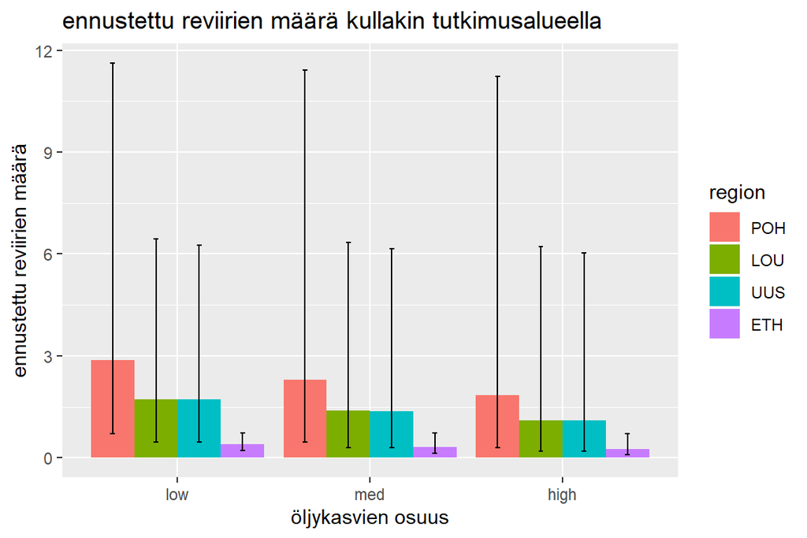

```r
predictions$treat <- factor(predictions$treat, levels = c('low', 'med', 'high'))

predictions$region <- factor(predictions$region, levels = c('POH', 'LOU', 'UUS', 'ETH'))

#kuvaajat
# Stacked barplot with multiple groups
ggplot(data=predictions, aes(x=treat, y=preds, fill=region)) +
  geom_bar(stat="identity", position=position_dodge()) +
  geom_errorbar(aes(ymin=lower95, ymax=upper95), width=.1,
                position=position_dodge(.9))+labs(title="ennustettu reviirien määrä kullakin tutkimusalueella", x = "öljykasvien osuus", y = "ennustettu reviirien määrä")
```

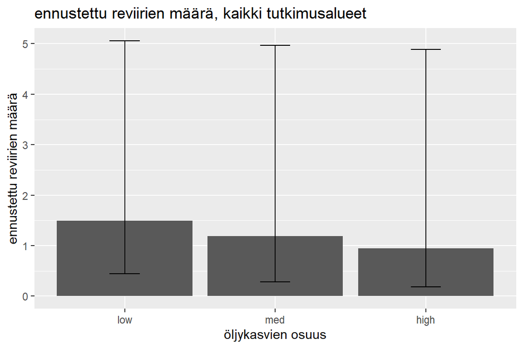

```r
ennusteet$kasit <- factor(ennusteet$kasit, levels = c('low', 'med', 'high'))

##kaikki alueet
ggplot(data=ennusteet, aes(x=kasit, y=enn)) +
  geom_bar(stat="identity", position=position_dodge()) +
  geom_errorbar(aes(ymin=ala95, ymax=yla95), width=.2,
                position=position_dodge(.9))+labs(title="ennustettu reviirien määrä, kaikki tutkimusalueet", x = "öljykasvien osuus", y = "ennustettu reviirien määrä")
```

HUOM!

*Käsin laskettaessa ennusteet pystyy laskemaan conditional average -estimaateilla (predict funktiolla on pakko käyttää full average -estimaatteja). Tosin luettuani tämän [vastauksen](https://stackoverflow.com/questions/53055050/predicted-values-with-mumin-throwing-error-when-full-false), en olekaan enää niin varma siitä, kumpia arvoja ennusteiden tekemisessä pitäisi käyttää.

*Käsin en osaa laskea kuin nuo esimerkin ohjeistamat yksittäisen ennusteen luottamusvälit(prediction intervals for individual values of Y). Yleensä varmaan ilmoitetaan ennemmin luottamusväli ennusteen keskiarvolle (confidence interval for the mean of Y). Mitenkähän se lasketaan käsin?

# Mallit glmmADMB-paketilla

```r
#mallit glmmadmb-funktiolla
M1=glmmadmb(terri ~ year
           + offset(Larea)
           + (1 + year| id),
           family="nbinom2",
           data=dataS)

M2=glmmadmb(terri ~ year + Abuild + Aroad + Astream + Ariver + agri5 + region
           + offset(Larea)
           + (1 + year| id),
           family="nbinom2",
           data=dataS)

M3=glmmadmb(terri ~ year + Abuild + Aroad + Astream + Ariver + agri5 + region + NeoPrior*year
           + offset(Larea)
           + (1 + year| id),
           family="nbinom2",
           data=dataS)

M4=glmmadmb(terri ~ year + Abuild + Aroad + Astream + Ariver + agri5 + region  + temp*year + prec*year
           + offset(Larea)
           + (1 + year| id),
           family="nbinom2",
           data=dataS)

M5=glmmadmb(terri ~ year + Abuild + Aroad + Astream + Ariver + agri5 + region + shanG*year + open*year
           + offset(Larea)
           + (1 + year| id),
           family="nbinom2",
           data=dataS)

M6=glmmadmb(terri ~ year + Abuild + Aroad + Astream + Ariver + agri5 + region + NeoPrior*year + shanG*year + open*year
           + offset(Larea)
           + (1 + year| id),
           family="nbinom2",
           data=dataS)

M7=glmmadmb(terri ~ year + Abuild + Aroad + Astream + Ariver + agri5 + region + NeoPrior*year + temp*year + prec*year
           + offset(Larea)
           + (1 + year| id),
           family="nbinom2",
           data=dataS)

M8=glmmadmb(terri ~ year + Abuild + Aroad + Astream + Ariver + agri5 + region + shanG*year + open*year + temp*year + prec*year
           + offset(Larea)
           + (1 + year| id),
           family="nbinom2",
           data=dataS)

M9=glmmadmb(terri ~ year + Abuild + Aroad + Astream + Ariver + agri5 + region + NeoPrior*year + shanG*year + open*year + temp*year + prec*year
           + offset(Larea)
           + (1 + year| id),
           family="nbinom2",
           data=dataS)
```

Parhaimman mallit etsintä

```r
#Malli M9 on globaalimalli, joka sisältää kaiken.
#sen summarya tutkailemalla voi huomata jo nyt, jos malli olisi ihan päin honkia.
summary(M9)
```

```
##
## Call:
## glmmadmb(formula = terri ~ year + Abuild + Aroad + Astream +
##     Ariver + agri5 + region + NeoPrior * year + shanG * year +
##     open * year + temp * year + prec * year + offset(Larea) +
##     (1 + year | id), data = dataS, family = "nbinom2")
##
## AIC: 5118.3
##
## Coefficients:
##               Estimate Std. Error z value Pr(>|z|)
## (Intercept)    -0.6610     0.2990   -2.21   0.0271 *
## year           -1.0410     0.1360   -7.66  1.9e-14 ***
## Abuild         -0.1888     0.1726   -1.09   0.2740
## Aroad           0.2323     0.1587    1.46   0.1432
## Astream         0.0539     0.1312    0.41   0.6813
## Ariver          0.3146     0.1207    2.61   0.0092 **
## agri5           0.5379     0.1489    3.61   0.0003 ***
## regionLOU       1.8028     0.3296    5.47  4.5e-08 ***
## regionPOH       2.3869     0.3491    6.84  8.0e-12 ***
## regionUUS       1.8182     0.3129    5.81  6.2e-09 ***
## NeoPrior       -0.1328     0.0639   -2.08   0.0377 *
## shanG           0.0630     0.0661    0.95   0.3405
## open           -0.0297     0.0810   -0.37   0.7140
## temp            0.1267     0.0461    2.75   0.0060 **
## prec           -0.0453     0.0455   -1.00   0.3186
## year:NeoPrior   0.0504     0.1351    0.37   0.7094
## year:shanG      0.1405     0.1296    1.08   0.2781
## year:open       0.0722     0.1615    0.45   0.6548
## year:temp       0.0644     0.0986    0.65   0.5139
## year:prec      -0.1562     0.0805   -1.94   0.0525 .
## ---
## Signif. codes:  0 '***' 0.001 '**' 0.01 '*' 0.05 '.' 0.1 ' ' 1
##
## Number of observations: total=1416, id=270
## Random effect variance(s):
```

```
## Group=id
##             Variance StdDev
## (Intercept)   0.6792 0.8241
## year          0.8057 0.8976
##
## Negative binomial dispersion parameter: 19.655 (std. err.: 6.2769)
##
## Log-likelihood: -2536.15
```

```r
#tarkistetaan ettei globaalimalli ole ylidispersoitunut
E2 <- resid(M9, type = "pearson")
N  <- nrow(dataS)
p  <- 23 + 3  #2 sigmas and 1 size/k/theta NB parameter
sum(E2^2) / (N - p)
```

```
## [1] 0.738385
```

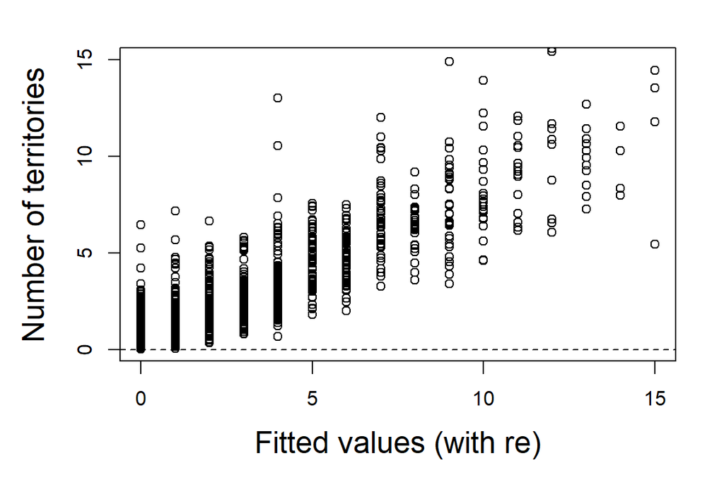

```r
#globaalimalli on hieman alidispersoitunut, 0.74, onko tämä ongelma?

#How good is the model performing?
F9 <- fitted(M9)
par(mfrow = c(1,1), cex.lab = 1.5, mar = c(5,5,2,2))
plot(x = dataS$terri,
     y = F9,
     xlab = "Fitted values (with re)",
     ylab = "Number of territories",
     xlim = c(0,15),
     ylim = c(0,15))
abline(h = 0, lty = 2)
```

```r
cor(dataS$terri, F9)
```

```
## [1] 0.9042416
```

```r
output<-model.sel(M1,M2,M3,M4,M5,M6,M7,M8,M9)
output
```

```
## Model selection table
##      (Int)    yer off(Lar)     Abl    ag5    Arv    Ard     Ast rgn
## M7 -0.6545 -1.025        + -0.1890 0.5260 0.3103 0.2251 0.03899   +
## M4 -0.7130 -1.036        + -0.1867 0.5289 0.3042 0.2168 0.03557   +
## M2 -0.7155 -1.078        + -0.1826 0.5291 0.3057 0.2062 0.03424   +
## M3 -0.6596 -1.069        + -0.1840 0.5271 0.3113 0.2136 0.03700   +
## M9 -0.6610 -1.041        + -0.1888 0.5379 0.3146 0.2323 0.05387   +
## M8 -0.7160 -1.054        + -0.1880 0.5444 0.3085 0.2271 0.05236   +
## M5 -0.7195 -1.094        + -0.1832 0.5470 0.3096 0.2164 0.05186   +
## M6 -0.6686 -1.083        + -0.1834 0.5416 0.3153 0.2206 0.05291   +
## M1  1.1950 -1.081        +
##        NPr NPr:yer      prc    tmp prc:yer tmp:yer      opn     shG
## M7 -0.1366 0.06391 -0.04490 0.1291 -0.1488 0.06697
## M4                 -0.04401 0.1235 -0.1496 0.06473
## M2
## M3 -0.1244 0.06994
## M9 -0.1328 0.05036 -0.04534 0.1267 -0.1562 0.06437 -0.02969 0.06303
## M8                 -0.04381 0.1205 -0.1575 0.06214 -0.04194 0.05905
## M5                                                 -0.05961 0.06203
## M6 -0.1202 0.05091                                 -0.04951 0.06643
## M1
##    opn:yer shG:yer df   logLik   AICc delta weight
## M7                 19 -2537.57 5113.7  0.00  0.425
## M4                 17 -2539.97 5114.4  0.69  0.301
## M2                 13 -2545.13 5116.5  2.84  0.103
## M3                 15 -2543.12 5116.6  2.90  0.100
## M9 0.07219  0.1405 23 -2536.15 5119.1  5.41  0.028
## M8 0.10680  0.1529 21 -2538.36 5119.4  5.70  0.025
## M5 0.13440  0.1324 17 -2543.38 5121.2  7.51  0.010
## M6 0.10480  0.1202 19 -2541.57 5121.7  8.00  0.008
## M1                  5 -2592.69 5195.4 81.74  0.000
## Models ranked by AICc(x)
## Random terms (all models):
## '1 + year | id'
```

```r
AIC(M1,M2,M3,M4,M5,M6,M7,M8,M9)
```

```
##    df     AIC
## M1  5 5195.38
## M2 13 5116.26
## M3 15 5116.24
## M4 17 5113.94
## M5 17 5120.76
## M6 19 5121.14
## M7 19 5113.14
## M8 21 5118.72
## M9 23 5118.30
```

```r
topmodels = get.models(output,cumsum(weight)<=0.95)

aver=model.avg(topmodels, revised.var = TRUE, fit=TRUE)
summary(aver)
```

```
##
## Call:
## model.avg(object = topmodels, fit = TRUE, revised.var = TRUE)
##
## Component model call:
## glmmadmb(formula = <4 unique values>, data = dataS, family =
##      nbinom2)
##
## Component models:
##                                  df   logLik    AICc delta weight
## 1/2/3/4/5/6/7/8/9/10/11/12/13/14 19 -2537.57 5113.68  0.00   0.46
## 1/2/3/4/5/7/8/9/10/11/13/14      17 -2539.97 5114.38  0.69   0.32
## 1/2/3/4/5/7/9/11                 13 -2545.13 5116.52  2.84   0.11
## 1/2/3/4/5/6/7/9/11/12            15 -2543.12 5116.58  2.90   0.11
##
## Term codes:
##        Abuild         agri5        Ariver         Aroad       Astream
##             1             2             3             4             5
##      NeoPrior offset(Larea)          prec        region          temp
##             6             7             8             9            10
##          year NeoPrior:year     prec:year     temp:year
##            11            12            13            14
##
## Model-averaged coefficients:
## (full average)
##               Estimate Std. Error Adjusted SE z value Pr(>|z|)
## (Intercept)   -0.68075    0.30081     0.30107   2.261 0.023754 *
## year          -1.03937    0.13464     0.13476   7.713  < 2e-16 ***
## Abuild        -0.18699    0.17280     0.17295   1.081 0.279617
## Aroad          0.21908    0.15875     0.15889   1.379 0.167938
## Astream        0.03714    0.13121     0.13133   0.283 0.777321
## Ariver         0.30794    0.12097     0.12108   2.543 0.010981 *
## agri5          0.52739    0.14833     0.14846   3.552 0.000382 ***
## regionLOU      1.83620    0.33132     0.33161   5.537  < 2e-16 ***
## regionPOH      2.41076    0.35166     0.35196   6.850  < 2e-16 ***
## regionUUS      1.84115    0.31539     0.31566   5.833  < 2e-16 ***
## NeoPrior      -0.07592    0.08209     0.08212   0.925 0.355187
## temp           0.09907    0.06631     0.06633   1.494 0.135285
## prec          -0.03480    0.04424     0.04427   0.786 0.431737
## NeoPrior:year  0.03678    0.10545     0.10553   0.349 0.727461
```

[output cut: 8 more lines]

```
## Aroad          0.21908    0.15875     0.15889   1.379 0.167938
## Astream        0.03714    0.13121     0.13133   0.283 0.777321
## Ariver         0.30794    0.12097     0.12108   2.543 0.010981 *
## agri5          0.52739    0.14833     0.14846   3.552 0.000382 ***
## regionLOU      1.83620    0.33132     0.33161   5.537  < 2e-16 ***
## regionPOH      2.41076    0.35166     0.35196   6.850  < 2e-16 ***
## regionUUS      1.84115    0.31539     0.31566   5.833  < 2e-16 ***
## NeoPrior      -0.13429    0.06388     0.06394   2.100 0.035700 *
## temp           0.12676    0.04600     0.04604   2.753 0.005905 **
## prec          -0.04453    0.04550     0.04554   0.978 0.328185
## NeoPrior:year  0.06506    0.13353     0.13364   0.487 0.626409
## temp:year      0.06604    0.09810     0.09818   0.673 0.501160
## prec:year     -0.14910    0.08076     0.08083   1.845 0.065090 .
## ---
## Signif. codes:  0 '***' 0.001 '**' 0.01 '*' 0.05 '.' 0.1 ' ' 1
```

```r
coef(aver)
```

```
##   (Intercept)          year        Abuild         Aroad       Astream
##   -0.68074620   -1.03936985   -0.18699281    0.21908154    0.03714115
##        Ariver         agri5     regionLOU     regionPOH     regionUUS
##    0.30794323    0.52738876    1.83619553    2.41076069    1.84115371
##      NeoPrior          temp          prec NeoPrior:year     temp:year
##   -0.13429456    0.12675983   -0.04453024    0.06505529    0.06604281
##     prec:year
##   -0.14910384
```

```r
confint(aver)
```

```
##                     2.5 %       97.5 %
## (Intercept)   -1.27083279 -0.090659614
## year          -1.30348779 -0.775251909
## Abuild        -0.52597340  0.151987775
## Aroad         -0.09232963  0.530492718
## Astream       -0.22025739  0.294539695
## Ariver         0.07063141  0.545255056
## agri5          0.23641877  0.818358751
## regionLOU      1.18626038  2.486130689
## regionPOH      1.72093194  3.100589442
## regionUUS      1.22246931  2.459838106
## NeoPrior      -0.25961443 -0.008974693
## temp           0.03651544  0.217004209
## prec          -0.13379168  0.044731200
## NeoPrior:year -0.19687816  0.326988736
## temp:year     -0.12638779  0.258473402
## prec:year     -0.30752954  0.009321864
```

```r
#taulukkoa taas yritän tehdä..
m_coefs <- coefTable(aver, full=F, adjust.se = TRUE) #full=T tarkoittaa, että estimaatit on arvioitu full average menetelmällä vs. conditional average, joita käytin käsintehdyissä ennusteissa. 'SE' on tässä nimenomaan adjusted SE.
coefnames <- row.names(m_coefs)
m_coefs <- as.data.frame(m_coefs)
m_coefs <- mutate(m_coefs,
                   coefficient = coefnames,
                   t = Estimate / `Std. Error`,
                   p = pt(abs(t), df = 1397, lower.tail = FALSE), #en tiedä onko df oikein. Mutta sen muuttaminen ei muuta tuloksia?!
                   lower95 = Estimate - 1.96 * `Std. Error`,
                   upper95 = Estimate + 1.96 * `Std. Error`) %>% select(coefficient, Estimate, `Std. Error`, t, p, lower95, upper95)
knitr::kable(m_coefs, digits = 2)
```

| coefficient | Estimate | Std. Error | t | p | lower95 | upper95 |
| --- | --- | --- | --- | --- | --- | --- |
| (Intercept) | -0.68 | 0.30 | -2.26 | 0.01 | -1.27 | -0.09 |
| year | -1.04 | 0.13 | -7.71 | 0.00 | -1.30 | -0.78 |
| Abuild | -0.19 | 0.17 | -1.08 | 0.14 | -0.53 | 0.15 |
| Aroad | 0.22 | 0.16 | 1.38 | 0.08 | -0.09 | 0.53 |
| Astream | 0.04 | 0.13 | 0.28 | 0.39 | -0.22 | 0.29 |
| Ariver | 0.31 | 0.12 | 2.54 | 0.01 | 0.07 | 0.55 |
| agri5 | 0.53 | 0.15 | 3.55 | 0.00 | 0.24 | 0.82 |
| regionLOU | 1.84 | 0.33 | 5.54 | 0.00 | 1.19 | 2.49 |
| regionPOH | 2.41 | 0.35 | 6.85 | 0.00 | 1.72 | 3.10 |
| regionUUS | 1.84 | 0.32 | 5.83 | 0.00 | 1.22 | 2.46 |
| NeoPrior | -0.13 | 0.06 | -2.10 | 0.02 | -0.26 | -0.01 |
| temp | 0.13 | 0.05 | 2.75 | 0.00 | 0.04 | 0.22 |
| prec | -0.04 | 0.05 | -0.98 | 0.16 | -0.13 | 0.04 |
| NeoPrior:year | 0.07 | 0.13 | 0.49 | 0.31 | -0.20 | 0.33 |
| temp:year | 0.07 | 0.10 | 0.67 | 0.25 | -0.13 | 0.26 |
| prec:year | -0.15 | 0.08 | -1.84 | 0.03 | -0.31 | 0.01 |

```r
coefs=m_coefs
coefs$coefficient=factor(coefs$coefficient)
coefs$signi=factor(ifelse(coefs$p >= 0.03 , 'N', 'Y'))
knitr::kable(coefs, digits = 2)
```

| coefficient | Estimate | Std. Error | t | p | lower95 | upper95 | signi |
| --- | --- | --- | --- | --- | --- | --- | --- |
| (Intercept) | -0.68 | 0.30 | -2.26 | 0.01 | -1.27 | -0.09 | Y |
| year | -1.04 | 0.13 | -7.71 | 0.00 | -1.30 | -0.78 | Y |
| Abuild | -0.19 | 0.17 | -1.08 | 0.14 | -0.53 | 0.15 | N |
| Aroad | 0.22 | 0.16 | 1.38 | 0.08 | -0.09 | 0.53 | N |
| Astream | 0.04 | 0.13 | 0.28 | 0.39 | -0.22 | 0.29 | N |
| Ariver | 0.31 | 0.12 | 2.54 | 0.01 | 0.07 | 0.55 | Y |
| agri5 | 0.53 | 0.15 | 3.55 | 0.00 | 0.24 | 0.82 | Y |
| regionLOU | 1.84 | 0.33 | 5.54 | 0.00 | 1.19 | 2.49 | Y |
| regionPOH | 2.41 | 0.35 | 6.85 | 0.00 | 1.72 | 3.10 | Y |
| regionUUS | 1.84 | 0.32 | 5.83 | 0.00 | 1.22 | 2.46 | Y |
| NeoPrior | -0.13 | 0.06 | -2.10 | 0.02 | -0.26 | -0.01 | Y |
| temp | 0.13 | 0.05 | 2.75 | 0.00 | 0.04 | 0.22 | Y |
| prec | -0.04 | 0.05 | -0.98 | 0.16 | -0.13 | 0.04 | N |
| NeoPrior:year | 0.07 | 0.13 | 0.49 | 0.31 | -0.20 | 0.33 | N |
| temp:year | 0.07 | 0.10 | 0.67 | 0.25 | -0.13 | 0.26 | N |
| prec:year | -0.15 | 0.08 | -1.84 | 0.03 | -0.31 | 0.01 | N |

Piirrän kuvaajia regressiokertoimista ja niiden luottamusvälit. Nämä lasketaaan nyt siis conditional average estimaateilla.

Regressiokertoimet ja niiden SE:t

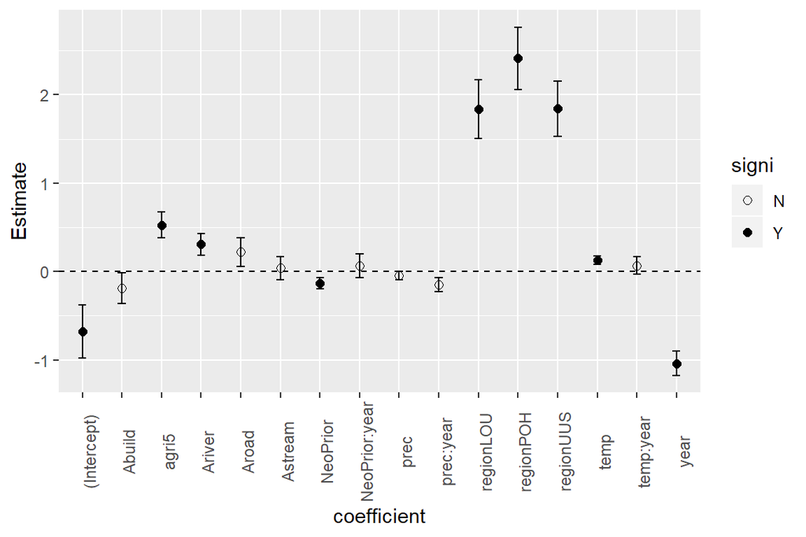

```r
ggplot(data= coefs, aes(coefficient, Estimate,group=signi)) +
  geom_point(aes(shape=signi), size=2) + scale_shape_manual(values=c(1,16)) +
  geom_errorbar(data = coefs, aes(coefficient, Estimate, ymin=Estimate - `Std. Error`, ymax = Estimate + `Std. Error`), width=0.2) +
  theme(axis.text.x = element_text(angle = 90)) +
  geom_hline(yintercept=0,linetype="dashed")
```

SE:t kertovat kuinka kauas oikeasta populaation keskiarvosta sun otoksien keskiarvot sijoittuvat. Kertoo siis otosvirheestä (vaihtelusta mitä otokset sisältävät, otoskoko vaikuttaa).

Regressiokertoimet ja 95% luottamusvälit

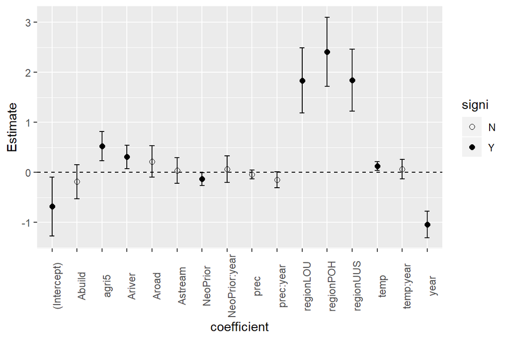

```r
ggplot(data= coefs, aes(coefficient, Estimate,group=signi)) +
  geom_point(aes(shape=signi), size=2) + scale_shape_manual(values=c(1,16)) +
  geom_errorbar(data = coefs, aes(coefficient, Estimate, ymin=lower95, ymax = upper95), width=0.2) +
  theme(axis.text.x = element_text(angle = 90)) +
  geom_hline(yintercept=0,linetype="dashed")
```

## ennusteet predict-funktiolla

```r
#predictions
newdata <- expand.grid(NeoPrior= with(dataS, c(0.13, 1.85, 3.58)),
                       year = mean(dataS$year),
                       Abuild = mean(dataS$Abuild),
                       Aroad = mean(dataS$Aroad),
                       Astream = mean(dataS$Astream),
                       Ariver = mean(dataS$Ariver),
                       agri5 = mean(dataS$agri5),
                       region = levels(dataS$region),
                       temp = mean(dataS$temp),
                       prec = mean(dataS$prec),
                       Larea=mean(dataS$Larea)) #näissä ennusteissa on mukana pinta-ala offsetti, vrt. käsintehtyihin ennusteisiin

pred.se <- predict(aver, type="link", re.form=NA,se.fit=TRUE, full=T, newdata)
#nämä ennusteet lasketaan nyt full averaged eikä conditional arvoista. Varmaan sen takia tulokset hieman erilaiset?

newdata$fit <- pred.se$fit
newdata$SE <- pred.se$se
newdata$upr=newdata$fit+1.96*newdata$SE
newdata$lwr=newdata$fit-1.96*newdata$SE

newdata$fitX <-exp(newdata$fit)
newdata$SEX<-exp(newdata$SE)
newdata$uprX=exp(newdata$upr)
newdata$lwrX=  exp(newdata$lwr)

newdata
```

```
##    NeoPrior         year       Abuild        Aroad      Astream
## 1      0.13 1.224611e-15 2.475572e-17 1.454152e-16 1.531412e-18
## 2      1.85 1.224611e-15 2.475572e-17 1.454152e-16 1.531412e-18
## 3      3.58 1.224611e-15 2.475572e-17 1.454152e-16 1.531412e-18
## 4      0.13 1.224611e-15 2.475572e-17 1.454152e-16 1.531412e-18
## 5      1.85 1.224611e-15 2.475572e-17 1.454152e-16 1.531412e-18
## 6      3.58 1.224611e-15 2.475572e-17 1.454152e-16 1.531412e-18
## 7      0.13 1.224611e-15 2.475572e-17 1.454152e-16 1.531412e-18
## 8      1.85 1.224611e-15 2.475572e-17 1.454152e-16 1.531412e-18
## 9      3.58 1.224611e-15 2.475572e-17 1.454152e-16 1.531412e-18
## 10     0.13 1.224611e-15 2.475572e-17 1.454152e-16 1.531412e-18
## 11     1.85 1.224611e-15 2.475572e-17 1.454152e-16 1.531412e-18
## 12     3.58 1.224611e-15 2.475572e-17 1.454152e-16 1.531412e-18
##          Ariver         agri5 region         temp          prec      Larea
## 1  1.955419e-17 -7.107634e-17    ETH 1.917879e-16 -8.239751e-17 -0.5355369
```

[output cut: 37 more lines]

## Kuvaaja ennusteille + luottamusvälit

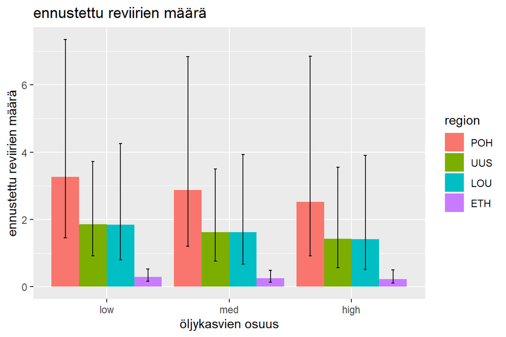

```r
newdata$region <- factor(newdata$region, levels = c('POH', 'UUS', 'LOU', 'ETH'))
newdata$NeoPrior=as.character(newdata$NeoPrior)
newdata$NeoPrior=revalue(newdata$NeoPrior,c("0.13"="low","1.85"="med","3.58"="high"))
newdata$NeoPrior <- factor(newdata$NeoPrior, levels = c('low', 'med', 'high'))

ggplot(newdata, aes(x=NeoPrior, y=fitX, fill=region)) +
  geom_bar(stat="identity", position=position_dodge()) +
  geom_errorbar(aes(ymin=lwrX, ymax=uprX), width=.1, position=position_dodge(0.9))+labs(title="ennustettu reviirien määrä", x = "öljykasvien osuus", y = "ennustettu reviirien määrä")
```

HUOM!

Predict-funktio laskee ennusteet hieman erilailla kuin käsin laskettaessa. Katso funktiosta lisää [täältä](https://rdrr.io/cran/MuMIn/man/predict.averaging.html). Funktio käyttää full average estimaatteja ja laskee ennusteet jokaisesta jatkoon valitusta mallista erikseen. Tällöin NeoPrior saa arvon nolla joissain malleissa (missä se ei siis esiinny muuttujana ja on täten vähän pienempi vaikutukseltaan).

Ennusteet lasketaan siis eri estimaateilla kuin mille aiemmin piirsin kuvaajia ja joihin perustan arvioni muuttujien merkityksestä. Onko tässä suuri ristiriita? Ongelma ratkeaisi, jos predict-funktio osaisi tehdä ennusteita conditional average estimaateista.

# Mallit ilman interaktioita

```r
#mallit ilman interaktioita
I1=glmmTMB(terri ~ year
           + offset(Larea)
           + (1 + year| id),
           family=nbinom2,
           data=dataS,
           REML=FALSE)

I2=glmmTMB(terri ~ year + Abuild + Aroad + Astream + Ariver + agri5 + region
           + offset(Larea)
           + (1 + year| id),
           family=nbinom2,
           data=dataS,
           REML=FALSE)

I3=glmmTMB(terri ~ year + Abuild + Aroad + Astream + Ariver + agri5 + region + NeoPrior
           + offset(Larea)
           + (1 + year| id),
           family=nbinom2,
           data=dataS,
           REML=FALSE)

I4=glmmTMB(terri ~ year + Abuild + Aroad + Astream + Ariver + agri5 + region  + temp + prec
           + offset(Larea)
           + (1 + year| id),
           family=nbinom2,
           data=dataS,
           REML=FALSE)

I5=glmmTMB(terri ~ year + Abuild + Aroad + Astream + Ariver + agri5 + region + shanG + open
           + offset(Larea)
           + (1 + year| id),
           family=nbinom2,
           data=dataS,
           REML=FALSE)

I6=glmmTMB(terri ~ year + Abuild + Aroad + Astream + Ariver + agri5 + region + NeoPrior + shanG + open
           + offset(Larea)
           + (1 + year| id),
           family=nbinom2,
           data=dataS,
           REML=FALSE)

I7=glmmTMB(terri ~ year + Abuild + Aroad + Astream + Ariver + agri5 + region + NeoPrior + temp + prec
           + offset(Larea)
           + (1 + year| id),
           family=nbinom2,
           data=dataS,
           REML=FALSE)

I8=glmmTMB(terri ~ year + Abuild + Aroad + Astream + Ariver + agri5 + region + shanG + open + temp + prec
           + offset(Larea)
           + (1 + year| id),
           family=nbinom2,
           data=dataS,
           REML=FALSE)

I9=glmmTMB(terri ~ year + Abuild + Aroad + Astream + Ariver + agri5 + region + NeoPrior + shanG + open + temp + prec
           + offset(Larea)
           + (1 + year| id),
           family=nbinom2,
           data=dataS,
           REML=FALSE)
```

```r
#globaalimalli
summary(I9)
```

```
##  Family: nbinom2  ( log )
## Formula:
## terri ~ year + Abuild + Aroad + Astream + Ariver + agri5 + region +
##     NeoPrior + shanG + open + temp + prec + offset(Larea) + (1 +
##     year | id)
## Data: dataS
##
##      AIC      BIC   logLik deviance df.resid
##   5112.9   5212.7  -2537.4   5074.9     1397
##
## Random effects:
##
## Conditional model:
##  Groups Name        Variance Std.Dev. Corr
##  id     (Intercept) 0.6143   0.7838
##         year        0.6685   0.8176   0.33
## Number of obs: 1416, groups:  id, 270
##
## Overdispersion parameter for nbinom2 family (): 16.2
##
## Conditional model:
##              Estimate Std. Error z value Pr(>|z|)
## (Intercept) -0.358487   0.309227  -1.159 0.246333
## year        -0.969835   0.129493  -7.489 6.92e-14 ***
## Abuild      -0.144517   0.166540  -0.868 0.385524
## Aroad        0.237074   0.155833   1.521 0.128175
## Astream      0.077538   0.130151   0.596 0.551339
## Ariver       0.304217   0.120547   2.524 0.011614 *
## agri5        0.550305   0.143579   3.833 0.000127 ***
## regionLOU    1.470958   0.349074   4.214 2.51e-05 ***
## regionPOH    1.959733   0.386409   5.072 3.94e-07 ***
## regionUUS    1.462077   0.337959   4.326 1.52e-05 ***
## NeoPrior    -0.131797   0.063875  -2.063 0.039080 *
## shanG        0.075601   0.065590   1.153 0.249067
## open         0.003014   0.077860   0.039 0.969121
## temp         0.116995   0.045423   2.576 0.010004 *
## prec        -0.010343   0.040984  -0.252 0.800751
## ---
## Signif. codes:  0 '***' 0.001 '**' 0.01 '*' 0.05 '.' 0.1 ' ' 1
```

```r
#ranking
output1<-model.sel(I1,I2,I3,I4,I5,I6,I7,I8,I9)
output1
```

```
## Model selection table
##    cnd((Int)) dsp((Int)) cnd(yer) cnd(off(Lar)) cnd(Abl) cnd(ag5) cnd(Arv)
## I7    -0.3616          +  -0.9759             +  -0.1519   0.5508   0.3039
## I4    -0.3925          +  -0.9781             +  -0.1486   0.5563   0.2964
## I9    -0.3585          +  -0.9698             +  -0.1445   0.5503   0.3042
## I3    -0.4405          +  -1.0180             +  -0.1625   0.5477   0.3076
## I8    -0.3920          +  -0.9736             +  -0.1417   0.5567   0.2969
## I2    -0.4685          +  -1.0190             +  -0.1595   0.5530   0.3009
## I6    -0.4436          +  -1.0150             +  -0.1541   0.5521   0.3101
## I5    -0.4731          +  -1.0170             +  -0.1513   0.5581   0.3035
## I1     1.0870          +  -0.9832             +
##    cnd(Ard) cnd(Ast) cnd(rgn) cnd(NPr)  cnd(prc) cnd(tmp)  cnd(opn)
## I7   0.2434  0.07296        +  -0.1307 -0.010010   0.1200
## I4   0.2374  0.07197        +          -0.009987   0.1148
## I9   0.2371  0.07754        +  -0.1318 -0.010340   0.1170  0.003014
## I3   0.2302  0.06291        +  -0.1195
## I8   0.2311  0.07623        +          -0.010210   0.1115 -0.001503
## I2   0.2254  0.06235        +
## I6   0.2233  0.06901        +  -0.1206                    -0.023990
## I5   0.2187  0.06816        +                             -0.026960
## I1
##    cnd(shG) df    logLik   AICc delta weight
## I7          17 -2538.153 5110.7  0.00  0.530
## I4          16 -2540.290 5113.0  2.22  0.174
## I9  0.07560 19 -2537.446 5113.4  2.69  0.138
## I3          15 -2542.431 5115.2  4.46  0.057
## I8  0.07364 18 -2539.602 5115.7  4.95  0.045
## I2          14 -2544.203 5116.7  5.96  0.027
## I6  0.08266 17 -2541.405 5117.2  6.50  0.020
## I5  0.08053 16 -2543.200 5118.8  8.04  0.009
## I1           6 -2586.048 5184.2 73.41  0.000
## Models ranked by AICc(x)
## Random terms (all models):
## 'cond(1 + year | id)'
```

```r
#topmodels, kokeilenkin 4 deltaAICc
topmodels = get.models(output1,subset=delta<4)

#model averaging
ave=model.avg(topmodels, revised.var = TRUE)
summary(ave)
```

```
##
## Call:
## model.avg(object = topmodels, revised.var = TRUE)
##
## Component model call:
## glmmTMB(formula = terri ~ <3 unique rhs>, data = dataS, family =
##      nbinom2, REML = FALSE, ziformula = ~0, dispformula = ~1)
##
## Component models:
##                               df   logLik    AICc delta weight
## 1/2/3/4/5/6/7/9/10/12/13      17 -2538.15 5110.74  0.00   0.63
## 1/2/3/4/5/7/9/10/12/13        16 -2540.29 5112.97  2.22   0.21
## 1/2/3/4/5/6/7/8/9/10/11/12/13 19 -2537.45 5113.44  2.69   0.16
##
## Term codes:
##        cond(Abuild)         cond(agri5)        cond(Ariver)
##                   1                   2                   3
##         cond(Aroad)       cond(Astream)      cond(NeoPrior)
##                   4                   5                   6
## cond(offset(Larea))          cond(open)          cond(prec)
##                   7                   8                   9
##        cond(region)         cond(shanG)          cond(temp)
##                  10                  11                  12
##          cond(year)
##                  13
##
## Model-averaged coefficients:
## (full average)
##                   Estimate Std. Error Adjusted SE z value Pr(>|z|)
## cond((Int))     -0.3675043  0.3104988   0.3107672   1.183 0.236979
## cond(year)      -0.9753427  0.1286394   0.1287507   7.575  < 2e-16 ***
## cond(Abuild)    -0.1499707  0.1675078   0.1676528   0.895 0.371038
## cond(Aroad)      0.2411442  0.1569367   0.1570726   1.535 0.124725
## cond(Astream)    0.0735061  0.1310836   0.1311971   0.560 0.575294
## cond(Ariver)     0.3024075  0.1212743   0.1213792   2.491 0.012723 *
## cond(agri5)      0.5518841  0.1441935   0.1443183   3.824 0.000131 ***
## cond(regionLOU)  1.4857838  0.3504275   0.3507307   4.236 2.27e-05 ***
## cond(regionPOH)  1.9677585  0.3887636   0.3890994   5.057 4.00e-07 ***
## cond(regionUUS)  1.4704498  0.3383000   0.3385923   4.343 1.41e-05 ***
## cond(NeoPrior)  -0.1038566  0.0776612   0.0776971   1.337 0.181326
```

[output cut: 9 more lines]

```
## cond(Abuild)    -0.149971   0.167508    0.167653   0.895 0.371038
## cond(Aroad)      0.241144   0.156937    0.157073   1.535 0.124725
## cond(Astream)    0.073506   0.131084    0.131197   0.560 0.575294
## cond(Ariver)     0.302407   0.121274    0.121379   2.491 0.012723 *
## cond(agri5)      0.551884   0.144193    0.144318   3.824 0.000131 ***
## cond(regionLOU)  1.485784   0.350427    0.350731   4.236 2.27e-05 ***
## cond(regionPOH)  1.967759   0.388764    0.389099   5.057 4.00e-07 ***
## cond(regionUUS)  1.470450   0.338300    0.338592   4.343 1.41e-05 ***
## cond(NeoPrior)  -0.130951   0.063692    0.063747   2.054 0.039955 *
## cond(temp)       0.118436   0.045030    0.045068   2.628 0.008591 **
## cond(prec)      -0.010061   0.040823    0.040858   0.246 0.805494
## cond(shanG)      0.075601   0.065590    0.065647   1.152 0.249478
## cond(open)       0.003014   0.077860    0.077928   0.039 0.969148
## ---
## Signif. codes:  0 '***' 0.001 '**' 0.01 '*' 0.05 '.' 0.1 ' ' 1
```

```r
#estimaatit ja luottamusvälit
coef(ave)
```

```
##     cond((Int))      cond(year)    cond(Abuild)     cond(Aroad)
##    -0.367504325    -0.975342715    -0.149970696     0.241144159
##   cond(Astream)    cond(Ariver)     cond(agri5) cond(regionLOU)
##     0.073506071     0.302407452     0.551884116     1.485783847
## cond(regionPOH) cond(regionUUS)  cond(NeoPrior)      cond(temp)
##     1.967758515     1.470449774    -0.130950800     0.118436372
##      cond(prec)     cond(shanG)      cond(open)
##    -0.010061024     0.075600644     0.003013982
```

```r
#ja niille luottamusvälit
confint(ave)
```

```
##                       2.5 %       97.5 %
## cond((Int))     -0.97659683  0.241588184
## cond(year)      -1.22768948 -0.722995946
## cond(Abuild)    -0.47856415  0.178622759
## cond(Aroad)     -0.06671241  0.549000729
## cond(Astream)   -0.18363553  0.330647671
## cond(Ariver)     0.06450857  0.540306333
## cond(agri5)      0.26902540  0.834742834
## cond(regionLOU)  0.79836441  2.173203290
## cond(regionPOH)  1.20513776  2.730379271
## cond(regionUUS)  0.80682107  2.134078474
## cond(NeoPrior)  -0.25589344 -0.006008163
## cond(temp)       0.03010379  0.206768951
## cond(prec)      -0.09014157  0.070019519
## cond(shanG)     -0.05306563  0.204266917
## cond(open)      -0.14972162  0.155749587
```

```r
ma_coefs <- coefTable(ave, full=F, adjust.se = TRUE)
coefnames <- row.names(ma_coefs)
ma_coefs <- as.data.frame(ma_coefs)
ma_coefs <- mutate(ma_coefs,
                   coefficient = coefnames,
                   t = Estimate / `Std. Error`,
                   p = pt(abs(t), df = 1397, lower.tail = FALSE), #mikäs tää df olikaan? tulokset ei muutu vaikka olisi eri arvo
                   lower95 = Estimate - 1.96 * `Std. Error`,
                   upper95 = Estimate + 1.96 * `Std. Error`) %>% select(coefficient, Estimate, `Std. Error`, t, p, lower95, upper95)
knitr::kable(ma_coefs, digits = 2)
```

| coefficient | Estimate | Std. Error | t | p | lower95 | upper95 |
| --- | --- | --- | --- | --- | --- | --- |
| cond((Int)) | -0.37 | 0.31 | -1.18 | 0.12 | -0.98 | 0.24 |
| cond(year) | -0.98 | 0.13 | -7.58 | 0.00 | -1.23 | -0.72 |
| cond(Abuild) | -0.15 | 0.17 | -0.89 | 0.19 | -0.48 | 0.18 |
| cond(Aroad) | 0.24 | 0.16 | 1.54 | 0.06 | -0.07 | 0.55 |
| cond(Astream) | 0.07 | 0.13 | 0.56 | 0.29 | -0.18 | 0.33 |
| cond(Ariver) | 0.30 | 0.12 | 2.49 | 0.01 | 0.06 | 0.54 |
| cond(agri5) | 0.55 | 0.14 | 3.82 | 0.00 | 0.27 | 0.83 |
| cond(regionLOU) | 1.49 | 0.35 | 4.24 | 0.00 | 0.80 | 2.17 |
| cond(regionPOH) | 1.97 | 0.39 | 5.06 | 0.00 | 1.21 | 2.73 |
| cond(regionUUS) | 1.47 | 0.34 | 4.34 | 0.00 | 0.81 | 2.13 |
| cond(NeoPrior) | -0.13 | 0.06 | -2.05 | 0.02 | -0.26 | -0.01 |
| cond(temp) | 0.12 | 0.05 | 2.63 | 0.00 | 0.03 | 0.21 |
| cond(prec) | -0.01 | 0.04 | -0.25 | 0.40 | -0.09 | 0.07 |
| cond(shanG) | 0.08 | 0.07 | 1.15 | 0.12 | -0.05 | 0.20 |
| cond(open) | 0.00 | 0.08 | 0.04 | 0.48 | -0.15 | 0.16 |

```r
#nyt tulokset ovat hieman erilaisia
#Mutta edelleen year, river, agri5, region, NeoPrior ja temp ovat ainoita muuttujia, joilla luottamusvälin sisään
#ei mahdu nollaa eli ovat vaikutukseltaan jonkun suuntaisia edes.

#tässä voisi testata saanko samanlaiset ennusteet..
```

# Zuurin esimerkin mukaisesti

```r
#################################################################################################################

#Zuurin esimerkin mukaan analyysi menisi näin


#aloitetaan Poisson-mallilla
ZPois=glmer(terri ~ year + Abuild + Aroad + Astream + Ariver + agri5 + region + NeoPrior*year + temp*year + prec*year + open*year + shanG*year
           + offset(Larea)
           + (1 + year| id),
           family=poisson, glmerControl(optimizer="bobyqa", optCtrl=list(maxfun=100000)),
           data=dataS)

# Check for overdispersion
E2 <- resid(ZPois, type = "pearson")
N  <- nrow(dataS)
p  <- length(fixef(ZPois)) +2  #tuosta 2:sta en menisi takuuseen, että menikö oikein..
sum(E2^2) / (N - p)
```

```
## [1] 0.8264322
```

```r
#tai
check_overdispersion(ZPois)
```

```
## # Overdispersion test
##
##        dispersion ratio =    0.827
##   Pearson's Chi-Squared = 1152.047
##                 p-value =        1
```

```
## No overdispersion detected.
```

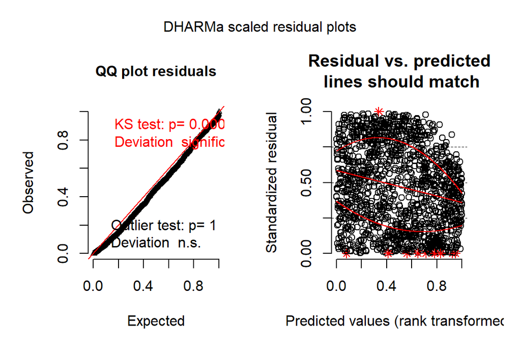

```r
#DHARMa-paketin kuvaajia mallin validointiin
simulateOutput=simulateResiduals(fittedModel = ZPois)
plot(simulateOutput)
```

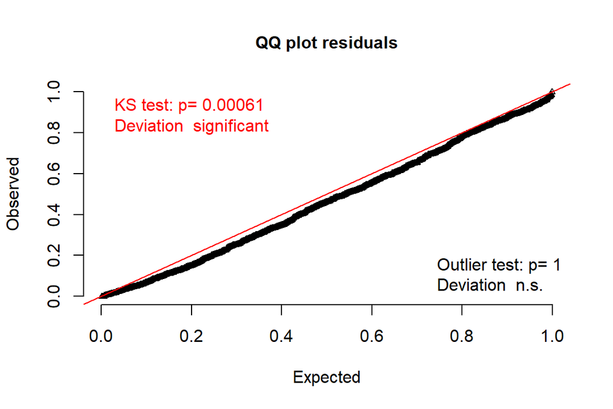

```
##
##  One-sample Kolmogorov-Smirnov test
##
## data:  simulationOutput$scaledResiduals
## D = 0.053438, p-value = 0.0006149
## alternative hypothesis: two-sided
```

```r
testUniformity(simulationOutput = simulateOutput)
```

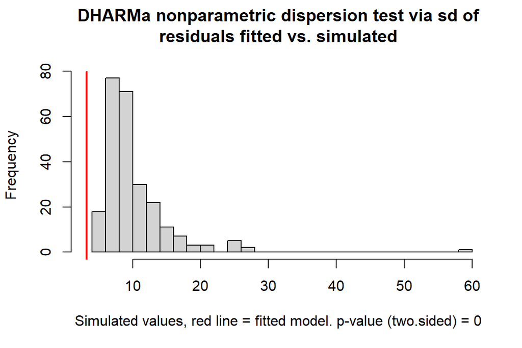

```
##
##  DHARMa nonparametric dispersion test via sd of residuals fitted
##  vs. simulated
##
## data:  simulationOutput
## ratioObsSim = 0.31748, p-value < 2.2e-16
## alternative hypothesis: two.sided
```

```r
testDispersion(simulateOutput)
```

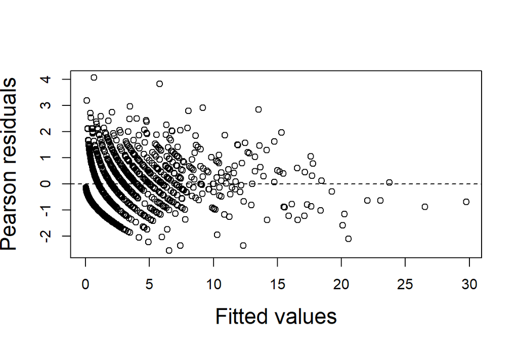

```r
#en osaa näitä kuvaajia tulkita, näyttäisi siltä, että Poisson malli ei olisi ainakaan overdispersed.
#Tarvitaanko siis neg.binomiaalijakauma?

# plot fitted values vs Pearson residuals
par(mfrow = c(1,1))
plot(x = fitted(ZPois),
     y = E2,
     xlab = "Fitted values",
     ylab = "Pearson residuals",
     cex.lab = 1.5)
abline(h = 0, lty = 2)
```

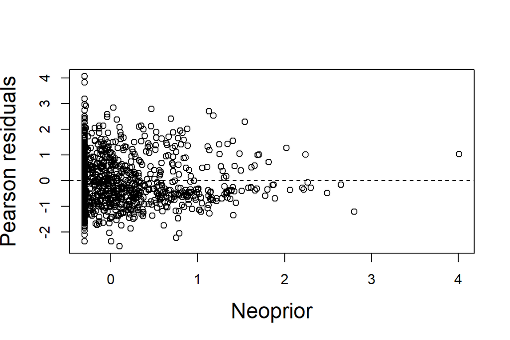

```r
# Entäpä tämän tulkinta? Ymmärtääkseni näistä kuvista ei haeta residuaalien tasaista jakautumista
#vaan mitä tahansa kuvioita. Onko tässä joku syy vaihtaa NB?

# plot Pearson residuals vs NeoPrior
par(mfrow = c(1,1))
plot(x = dataS$NeoPrior,
     y = E2,
     xlab = "Neoprior",
     ylab = "Pearson residuals",
     cex.lab = 1.5)
abline(h = 0, lty = 2)
```

```r
# Is there a pattern in here?
# Try fitting a smoother on the residuals
T1 <- gam(E2 ~ s(NeoPrior), data = dataS)
summary(T1)
```

```
##
## Family: gaussian
## Link function: identity
##
## Formula:
## E2 ~ s(NeoPrior)
##
## Parametric coefficients:
##             Estimate Std. Error t value Pr(>|t|)
## (Intercept) -0.07112    0.02385  -2.982  0.00291 **
## ---
## Signif. codes:  0 '***' 0.001 '**' 0.01 '*' 0.05 '.' 0.1 ' ' 1
##
## Approximate significance of smooth terms:
##              edf Ref.df     F p-value
## s(NeoPrior) 7.52  8.427 1.355   0.242
##
## R-sq.(adj) =  0.00456   Deviance explained = 0.985%
## GCV = 0.81029  Scale est. = 0.80542   n = 1416
```

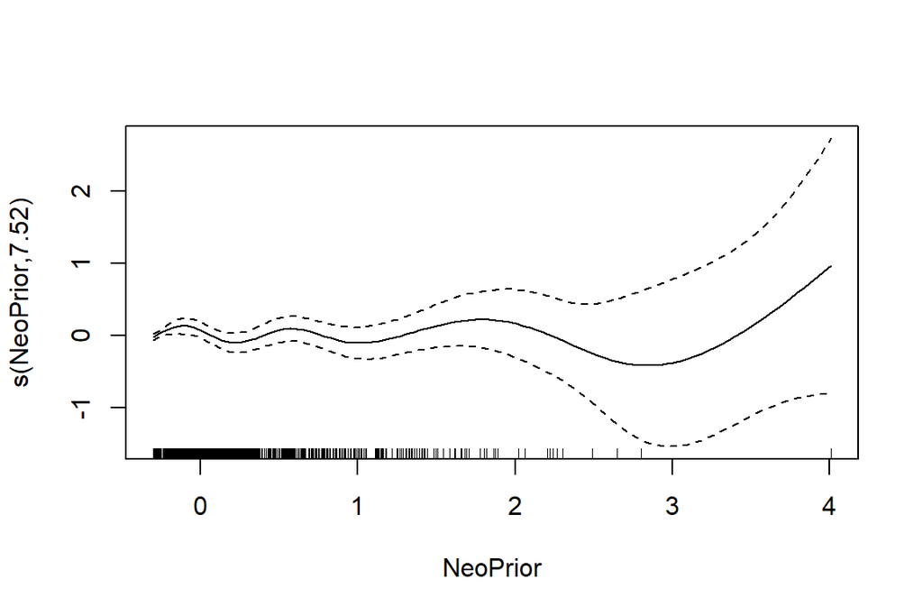

```r
plot(T1)
```

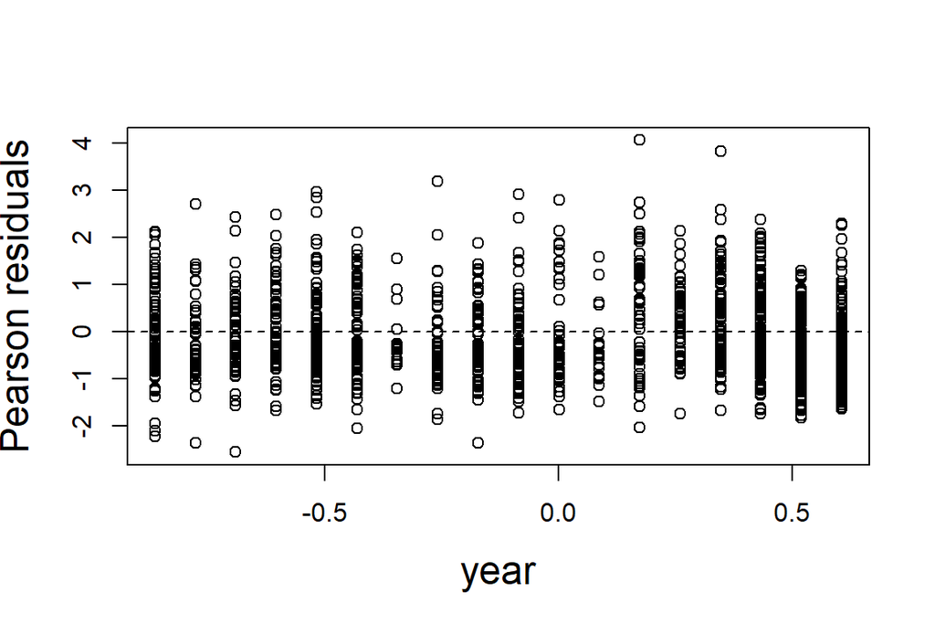

```r
# plot Pearson residuals vs year
par(mfrow = c(1,1))
plot(x = dataS$year,
     y = E2,
     xlab = "year",
     ylab = "Pearson residuals",
     cex.lab = 1.5)
abline(h = 0, lty = 2)
```

```r
# Is there a pattern in here?
# Try fitting a smoother on the residuals
T1 <- gam(E2 ~ s(year), data = dataS)
summary(T1)
```

```
##
## Family: gaussian
## Link function: identity
##
## Formula:
## E2 ~ s(year)
##
## Parametric coefficients:
##             Estimate Std. Error t value Pr(>|t|)
## (Intercept) -0.07112    0.02337  -3.044  0.00238 **
## ---
## Signif. codes:  0 '***' 0.001 '**' 0.01 '*' 0.05 '.' 0.1 ' ' 1
##
## Approximate significance of smooth terms:
##           edf Ref.df     F  p-value
## s(year) 6.617  7.726 8.749 3.21e-11 ***
## ---
## Signif. codes:  0 '***' 0.001 '**' 0.01 '*' 0.05 '.' 0.1 ' ' 1
##
## R-sq.(adj) =  0.0443   Deviance explained = 4.88%
## GCV = 0.77745  Scale est. = 0.77327   n = 1416
```

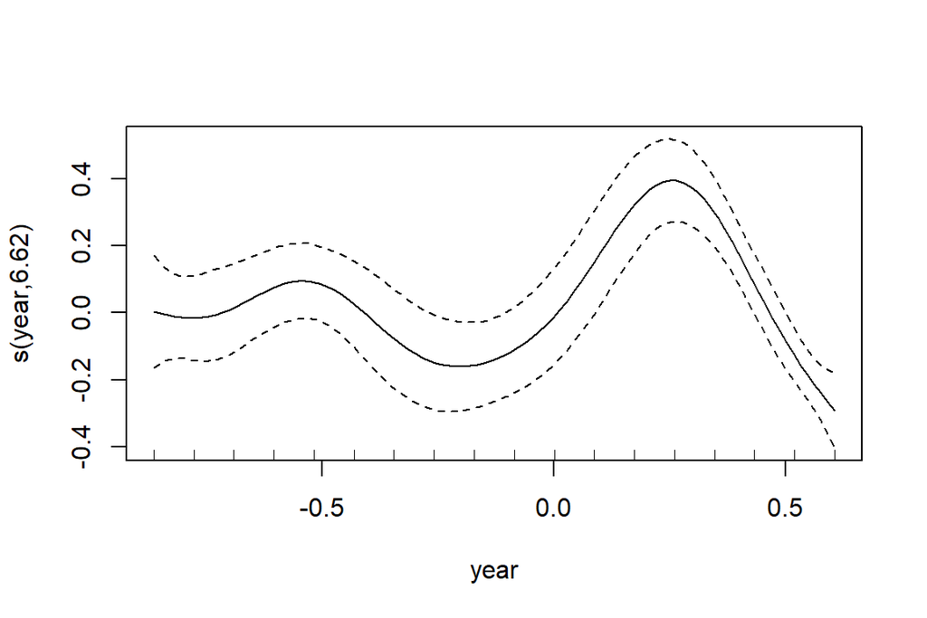

```r
plot(T1)
```

```r
#vuoden residuaaleissa taitaa olla kuvio?

#vaihdetaan NB-jakaumaan
ZNeg=glmer(terri ~ year + Abuild + Aroad + Astream + Ariver + agri5 + region + NeoPrior*year + temp*year + prec*year + open*year + shanG*year
            + offset(Larea)
            + (1 + year| id),
            family=nbinom2(), glmerControl(optimizer="bobyqa", optCtrl=list(maxfun=100000)),
            data=dataS)

#tai glmmTMB-funktiolla
ZNeg_TMB=glmmTMB(terri ~ year + Abuild + Aroad + Astream + Ariver + agri5 + region + NeoPrior*year + temp*year + prec*year + open*year + shanG*year
           + offset(Larea)
           + (1 + year| id),
           family="nbinom2",
           data=dataS)

# Check for overdispersion
E2 <- resid(ZNeg, type = "pearson")
N  <- nrow(dataS)
p  <- length(fixef(ZNeg)) + 2 + 1  #2 sigmas and 1 size/k/theta NB parameter (en taas olisi tästä niin varma)
sum(E2^2) / (N - p)
```

```
## [1] 0.3512276
```

```r
#Hmm.. underdispersion vain paheni?!

# Check for overdispersion
E2 <- resid(ZNeg_TMB, type = "pearson")
N  <- nrow(dataS)
p  <- length(fixef(ZNeg_TMB)$con) + 3  #2 sigmas and 1 size/k/theta NB parameter
sum(E2^2) / (N - p)
```

```
## [1] 0.7446616
```

```r
#hyvin erilainen dispersion statistic arvo glmmTMB-funktiolla, hmm?

summary(ZNeg)
```

```
## Generalized linear mixed model fit by maximum likelihood (Laplace
##   Approximation) [glmerMod]
##  Family: nbinom2  ( log )
## Formula:
## terri ~ year + Abuild + Aroad + Astream + Ariver + agri5 + region +
##     NeoPrior * year + temp * year + prec * year + open * year +
##     shanG * year + offset(Larea) + (1 + year | id)
##    Data: dataS
## Control:
## glmerControl(optimizer = "bobyqa", optCtrl = list(maxfun = 1e+05))
##
##      AIC      BIC   logLik deviance df.resid
##       NA       NA       NA       NA     1392
##
## Scaled residuals:
##     Min      1Q  Median      3Q     Max
## -1.4220 -0.7590 -0.2330  0.4864  4.9940
##
## Random effects:
##  Groups   Name        Variance Std.Dev. Corr
##  id       (Intercept) 0.4339   0.6587
##           year        0.4339   0.6587   0.00
##  Residual             0.4339   0.6587
## Number of obs: 1416, groups:  id, 270
##
## Fixed effects:
##                Estimate Std. Error t value Pr(>|z|)
## (Intercept)   -0.687533   0.232756  -2.954 0.003138 **
## year          -0.945133   0.091490 -10.330  < 2e-16 ***
## Abuild        -0.144763   0.141082  -1.026 0.304850
## Aroad          0.171305   0.131231   1.305 0.191766
## Astream        0.056667   0.110048   0.515 0.606599
## Ariver         0.307267   0.102041   3.011 0.002602 **
## agri5          0.446144   0.123797   3.604 0.000314 ***
## regionLOU      1.827608   0.261755   6.982 2.91e-12 ***
## regionPOH      2.417522   0.279337   8.655  < 2e-16 ***
## regionUUS      1.849239   0.246154   7.513 5.80e-14 ***
## NeoPrior      -0.127804   0.068416  -1.868 0.061755 .
## temp           0.086304   0.059860   1.442 0.149370
## prec          -0.101042   0.059420  -1.700 0.089042 .
## open          -0.001435   0.083185  -0.017 0.986236
## shanG          0.203233   0.071851   2.829 0.004676 **
## year:NeoPrior -0.062790   0.144501  -0.435 0.663902
## year:temp      0.221203   0.128017   1.728 0.084002 .
## year:prec     -0.123328   0.106567  -1.157 0.247156
## year:open     -0.093396   0.160513  -0.582 0.560660
## year:shanG    -0.134369   0.142620  -0.942 0.346117
## ---
## Signif. codes:  0 '***' 0.001 '**' 0.01 '*' 0.05 '.' 0.1 ' ' 1
```

```
##
## Correlation matrix not shown by default, as p = 20 > 12.
## Use print(x, correlation=TRUE)  or
##     vcov(x)        if you need it
```

```
## convergence code: 0
## Gradient contains NAs
```

```r
summary(ZNeg_TMB)
```

```
##  Family: nbinom2  ( log )
## Formula:
## terri ~ year + Abuild + Aroad + Astream + Ariver + agri5 + region +
##     NeoPrior * year + temp * year + prec * year + open * year +
##     shanG * year + offset(Larea) + (1 + year | id)
## Data: dataS
##
##      AIC      BIC   logLik deviance df.resid
##   5118.1   5244.3  -2535.1   5070.1     1392
##
## Random effects:
##
## Conditional model:
##  Groups Name        Variance Std.Dev. Corr
##  id     (Intercept) 0.6170   0.7855
##         year        0.7046   0.8394   0.30
## Number of obs: 1416, groups:  id, 270
##
## Overdispersion parameter for nbinom2 family (): 17.5
##
## Conditional model:
##                Estimate Std. Error z value Pr(>|z|)
## (Intercept)   -0.378592   0.320022  -1.183 0.236802
## year          -0.966319   0.135470  -7.133 9.81e-13 ***
## Abuild        -0.157282   0.168210  -0.935 0.349773
## Aroad          0.245799   0.156959   1.566 0.117347
## Astream        0.080299   0.130670   0.615 0.538875
## Ariver         0.308383   0.120867   2.551 0.010728 *
## agri5          0.558589   0.144722   3.860 0.000114 ***
## regionLOU      1.475421   0.361178   4.085 4.41e-05 ***
## regionPOH      1.995772   0.400755   4.980 6.36e-07 ***
## regionUUS      1.475137   0.351892   4.192 2.76e-05 ***
## NeoPrior      -0.130454   0.063808  -2.044 0.040905 *
## temp           0.137839   0.046969   2.935 0.003339 **
## prec          -0.048085   0.045910  -1.047 0.294927
## open          -0.004977   0.081401  -0.061 0.951243
## shanG          0.075768   0.066666   1.137 0.255735
## year:NeoPrior  0.025109   0.134798   0.186 0.852229
## year:temp      0.084151   0.099860   0.843 0.399405
## year:prec     -0.151726   0.081397  -1.864 0.062319 .
## year:open      0.023068   0.160382   0.144 0.885636
## year:shanG     0.084668   0.133624   0.634 0.526321
## ---
## Signif. codes:  0 '***' 0.001 '**' 0.01 '*' 0.05 '.' 0.1 ' ' 1
```